# Biodiversity of macrozoobenthic communities - 1

2017-10-30

## Community structure & composition

These are the basic analyses of the structure and composition of the zoobenthic communities in Burgas Bay for the thesis. The experimental setup included 3 parts:  
- seagrass/sand preliminary experiment in Sozopol Bay (2012)  
- sandy bottoms in Burgas Bay (2013-2014)  
- seagrass meadows in Burgas Bay (2013-2014)

These are the 3 datasets on which the same sets of analyses will be run.

This notebook describes the first steps of the analysis, from the import, cleaning & preparation of the data, to the basic descriptive statistics, preliminary analyses and plots.

First, set some basic options to control code chunks, evaluation behaviour, etc. (code won’t appear in the final report, as it’s just setup).

Now, define some subdirectories which will (hopefully) keep the project organized.

```r
data.dir <- "data"    # input data files
functions.dir <- "R"  # functions & scripts
save.dir <- "output"  # clean data, output from models & more complex calculations
figures.dir <- "figs" # plots & figures
```

Next, import the custom functions we’ll use in the analyses. They’re organized in a separate subdirectory, in several files by type of analysis, but we’ll import them manually (for now).

```r
source(file.path(functions.dir, "import_data.R"))
```

Import some necessary libraries.

```r
library(vegan)
library(viridis)
library(tidyverse)
```

Organize some commonly-used ggplot2 modifications into a more convenient (and less repetitive) format.

```r
## ggplot settings & things that I keep reusing
# ggplot_theme <- list(
#   theme_bw(),
#   theme(element_text(family = "Times"))
# )
## helper to adjust ggplot text size & avoid repetitions
text_size <- function(text.x = NULL,
                      text.y = NULL,
                      title.x = NULL,
                      title.y = NULL,
                      legend.text = NULL,
                      legend.title = NULL,
                      strip.x = NULL,
                      strip.y = NULL) {
  theme(axis.text.x = element_text(size = text.x),
        axis.text.y = element_text(size = text.y),
        axis.title.x = element_text(size = title.x),
        axis.title.y = element_text(size = title.y),
        legend.text = element_text(size = legend.text),
        legend.title = element_text(size = legend.title),
        strip.text.x = element_text(size = strip.x),
        strip.text.y = element_text(size = strip.y)
        )
  }
# log y/min + 1 transform - useful for species counts/biomass data visualization
log_y_min <- function(y) {
  log(y / min(y[y > 0]) + 1)
}
```

#### Macrozoobenthic communities in the sandy sediments of Burgas Bay (2013-2014)

Import the zoobenthic abundance & biomass data. The abundances are counts of organisms in each sample; the biomasses - wet weights of organisms in g. NOT expressed as individuals.m<sup>-2</sup> or g.m<sup>-2</sup> - it doesn’t matter for the calculations; will multiply by the corresponding values whenever needed for more presentable output - tables or plots.

```r
## import & check the abundance data. Dimensions should be 54 x 205 (5 metadata + 200 species columns); all species columns should be numeric.
(zoo.abnd.sand <- import_zoo_data(data.dir = data.dir,
                                 zoo.data = "zoo_abnd_sand_orig.csv",
                                 meta.labels = c("station", "month", "year", "habitat", "replicate")))
```

|  | station | month | year | habitat | replicate | Abra alba | Abra prismatica | Abra segmentum | Abra sp. | Acanthocardia tuberculata | Acari | Actiniaria | Alitta succinea | Ampelisca diadema | Ampharetidae | Amphibalanus improvisus | Amphipoda | Amphitritides gracilis | Ampithoe sp. | Anadara kagoshimensis | Aonides paucibranchiata | Apherusa bispinosa | Apseudopsis ostroumovi | Aricidea claudiae | Bathyporeia guilliamsoniana | Bittium reticulatum | Bivalvia undet. | Bodotria arenosa | Brachynotus sexdentatus | … |
| --- | --- | --- | --- | --- | --- | --- | --- | --- | --- | --- | --- | --- | --- | --- | --- | --- | --- | --- | --- | --- | --- | --- | --- | --- | --- | --- | --- | --- | --- | --- |
| 1 | Agalina | 6 | 2013 | S | a | 0 | 0 | 0 | 0 | 0 | 14 | 0 | 2 | 0 | 0 | 0 | 0 | 0 | 0 | 0 | 3 | 0 | 0 | 0 | 0 | 3 | 0 | 7 | 0 | … |
| 2 | Agalina | 6 | 2013 | S | b | 0 | 0 | 0 | 0 | 0 | 5 | 0 | 0 | 1 | 0 | 0 | 0 | 0 | 0 | 0 | 0 | 0 | 0 | 0 | 0 | 3 | 0 | 5 | 0 | … |
| 3 | Agalina | 6 | 2013 | S | c | 0 | 0 | 0 | 0 | 0 | 21 | 0 | 3 | 0 | 0 | 1 | 0 | 0 | 0 | 0 | 0 | 0 | 0 | 0 | 0 | 1 | 0 | 5 | 0 | … |
| 4 | Agalina | 7 | 2014 | S | a | 0 | 0 | 0 | 0 | 0 | 8 | 0 | 0 | 2 | 0 | 0 | 0 | 6 | 0 | 0 | 0 | 0 | 0 | 0 | 0 | 0 | 0 | 5 | 0 | … |
| 5 | Agalina | 7 | 2014 | S | b | 0 | 0 | 0 | 0 | 0 | 29 | 0 | 3 | 0 | 0 | 0 | 0 | 0 | 0 | 0 | 0 | 0 | 0 | 0 | 0 | 0 | 0 | 1 | 0 | … |
| 6 | Agalina | 7 | 2014 | S | c | 0 | 0 | 0 | 0 | 0 | 5 | 0 | 0 | 1 | 0 | 0 | 0 | 2 | 0 | 0 | 1 | 0 | 0 | 0 | 0 | 0 | 0 | 2 | 0 | … |
| 7 | Agalina | 9 | 2013 | S | a | 0 | 0 | 0 | 0 | 0 | 10 | 0 | 1 | 2 | 0 | 0 | 0 | 0 | 0 | 0 | 0 | 0 | 3 | 0 | 0 | 1 | 0 | 2 | 0 | … |
| 8 | Agalina | 9 | 2013 | S | b | 0 | 0 | 0 | 0 | 0 | 4 | 0 | 1 | 3 | 0 | 1 | 0 | 0 | 0 | 0 | 0 | 0 | 1 | 0 | 0 | 0 | 0 | 1 | 0 | … |
| 9 | Agalina | 9 | 2013 | S | c | 0 | 0 | 0 | 0 | 0 | 11 | 0 | 0 | 3 | 0 | 0 | 0 | 0 | 0 | 0 | 0 | 0 | 0 | 0 | 1 | 0 | 0 | 4 | 0 | … |
| 10 | Akin | 6 | 2013 | S | a | 0 | 0 | 0 | 0 | 0 | 0 | 0 | 0 | 1 | 0 | 1 | 0 | 0 | 0 | 0 | 0 | 0 | 0 | 0 | 7 | 8 | 0 | 0 | 0 | … |

[output cut: 44 more lines]

Convert the month and year back to numeric (they remained as character during import); then arrange the data frame - by station (first converting to factor), then year and month. This will be the convention used for all subsequent data frames.

```r
(zoo.abnd.sand <- zoo.abnd.sand %>%
  mutate(year = as.numeric(year),
         month = as.numeric(month),
         station = factor(station, levels = c("Kraimorie", "Chukalya", "Akin", "Sozopol", "Agalina", "Paraskeva"))) %>%
  arrange(station, year, month)
)
```

| station | month | year | habitat | replicate | Abra alba | Abra prismatica | Abra segmentum | Abra sp. | Acanthocardia tuberculata | Acari | Actiniaria | Alitta succinea | Ampelisca diadema | Ampharetidae | Amphibalanus improvisus | Amphipoda | Amphitritides gracilis | Ampithoe sp. | Anadara kagoshimensis | Aonides paucibranchiata | Apherusa bispinosa | Apseudopsis ostroumovi | Aricidea claudiae | Bathyporeia guilliamsoniana | Bittium reticulatum | Bivalvia undet. | Bodotria arenosa | Brachynotus sexdentatus | Brachystomia scalaris | … |
| --- | --- | --- | --- | --- | --- | --- | --- | --- | --- | --- | --- | --- | --- | --- | --- | --- | --- | --- | --- | --- | --- | --- | --- | --- | --- | --- | --- | --- | --- | --- |
| Kraimorie | 6 | 2013 | S | a | 11 | 0 | 0 | 0 | 0 | 0 | 0 | 2 | 6 | 0 | 3 | 0 | 0 | 0 | 1 | 0 | 0 | 0 | 0 | 0 | 38 | 0 | 0 | 0 | 0 | … |
| Kraimorie | 6 | 2013 | S | b | 5 | 0 | 0 | 0 | 0 | 0 | 0 | 0 | 4 | 0 | 0 | 0 | 0 | 0 | 8 | 0 | 0 | 0 | 0 | 0 | 17 | 0 | 0 | 1 | 0 | … |
| Kraimorie | 6 | 2013 | S | c | 8 | 0 | 0 | 0 | 0 | 0 | 0 | 0 | 0 | 0 | 1 | 0 | 0 | 0 | 5 | 0 | 0 | 0 | 0 | 0 | 22 | 0 | 0 | 0 | 0 | … |
| Kraimorie | 9 | 2013 | S | a | 5 | 0 | 0 | 0 | 0 | 0 | 0 | 3 | 2 | 0 | 0 | 0 | 0 | 0 | 12 | 0 | 0 | 0 | 1 | 0 | 10 | 0 | 0 | 0 | 0 | … |
| Kraimorie | 9 | 2013 | S | b | 1 | 0 | 0 | 0 | 0 | 0 | 0 | 2 | 0 | 0 | 1 | 0 | 0 | 0 | 5 | 0 | 0 | 0 | 0 | 0 | 5 | 0 | 0 | 0 | 0 | … |
| Kraimorie | 9 | 2013 | S | c | 2 | 0 | 0 | 0 | 0 | 0 | 0 | 1 | 5 | 0 | 1 | 0 | 0 | 0 | 1 | 0 | 0 | 0 | 0 | 0 | 21 | 0 | 0 | 0 | 0 | … |
| Kraimorie | 7 | 2014 | S | a | 8 | 0 | 0 | 0 | 0 | 0 | 0 | 0 | 4 | 0 | 0 | 0 | 0 | 0 | 7 | 0 | 0 | 0 | 0 | 0 | 4 | 0 | 0 | 0 | 0 | … |
| Kraimorie | 7 | 2014 | S | b | 3 | 0 | 0 | 0 | 0 | 0 | 0 | 1 | 1 | 0 | 2 | 0 | 0 | 0 | 7 | 0 | 0 | 0 | 3 | 0 | 23 | 0 | 0 | 2 | 0 | … |
| Kraimorie | 7 | 2014 | S | c | 4 | 0 | 0 | 0 | 0 | 0 | 0 | 0 | 2 | 0 | 2 | 0 | 0 | 0 | 11 | 0 | 0 | 0 | 0 | 0 | 28 | 0 | 0 | 1 | 0 | … |
| Chukalya | 6 | 2013 | S | a | 0 | 0 | 0 | 0 | 0 | 1 | 0 | 0 | 3 | 0 | 0 | 0 | 0 | 0 | 1 | 9 | 0 | 0 | 0 | 0 | 2 | 0 | 0 | 0 | 0 | … |

[output cut: 44 more lines]

Now on to the biomass!

```r
## import & check out the biomass data.
(zoo.biomass.sand <- import_zoo_data(data.dir = data.dir,
                                    zoo.data = "zoo_biomass_sand_orig.csv",
                                    meta.labels = c("station", "month", "year", "habitat", "replicate")))
```

|  | station | month | year | habitat | replicate | Abra alba | Abra prismatica | Abra segmentum | Abra sp. | Acanthocardia tuberculata | Acari | Actiniaria | Alitta succinea | Ampelisca diadema | Ampharetidae | Amphibalanus improvisus | Amphipoda | Amphitritides gracilis | Ampithoe sp. | Anadara kagoshimensis | Aonides paucibranchiata | Apherusa bispinosa | Apseudopsis ostroumovi | Aricidea claudiae | Bathyporeia guilliamsoniana | Bittium reticulatum | Bivalvia undet. | Bodotria arenosa | Brachynotus sexdentatus | … |
| --- | --- | --- | --- | --- | --- | --- | --- | --- | --- | --- | --- | --- | --- | --- | --- | --- | --- | --- | --- | --- | --- | --- | --- | --- | --- | --- | --- | --- | --- | --- |
| 1 | Agalina | 6 | 2013 | S | a | 0.0000 | 0 | 0 | 0.0000 | 0.0000 | 0.0011 | 0.0000 | 0.0005 | 0.0000 | 0 | 0.0000 | 0e+00 | 0.0000 | 0e+00 | 0.0000 | 0.0003 | 0 | 0e+00 | 0e+00 | 0.0000 | 0.0377 | 0 | 0.0031 | 0.0000 | … |
| 2 | Agalina | 6 | 2013 | S | b | 0.0000 | 0 | 0 | 0.0000 | 0.0000 | 0.0004 | 0.0000 | 0.0000 | 0.0002 | 0 | 0.0000 | 0e+00 | 0.0000 | 0e+00 | 0.0000 | 0.0000 | 0 | 0e+00 | 0e+00 | 0.0000 | 0.0345 | 0 | 0.0008 | 0.0000 | … |
| 3 | Agalina | 6 | 2013 | S | c | 0.0000 | 0 | 0 | 0.0000 | 0.0000 | 0.0022 | 0.0000 | 0.0010 | 0.0000 | 0 | 0.0024 | 0e+00 | 0.0000 | 0e+00 | 0.0000 | 0.0000 | 0 | 0e+00 | 0e+00 | 0.0000 | 0.0075 | 0 | 0.0005 | 0.0000 | … |
| 4 | Agalina | 7 | 2014 | S | a | 0.0000 | 0 | 0 | 0.0000 | 0.0000 | 0.0003 | 0.0000 | 0.0000 | 0.0066 | 0 | 0.0000 | 0e+00 | 0.0059 | 0e+00 | 0.0000 | 0.0000 | 0 | 0e+00 | 0e+00 | 0.0000 | 0.0000 | 0 | 0.0023 | 0.0000 | … |
| 5 | Agalina | 7 | 2014 | S | b | 0.0000 | 0 | 0 | 0.0000 | 0.0000 | 0.0006 | 0.0000 | 0.0026 | 0.0000 | 0 | 0.0000 | 0e+00 | 0.0000 | 0e+00 | 0.0000 | 0.0000 | 0 | 0e+00 | 0e+00 | 0.0000 | 0.0000 | 0 | 0.0001 | 0.0000 | … |
| 6 | Agalina | 7 | 2014 | S | c | 0.0000 | 0 | 0 | 0.0000 | 0.0000 | 0.0002 | 0.0000 | 0.0000 | 0.0001 | 0 | 0.0000 | 0e+00 | 0.0023 | 0e+00 | 0.0000 | 0.0030 | 0 | 0e+00 | 0e+00 | 0.0000 | 0.0000 | 0 | 0.0005 | 0.0000 | … |
| 7 | Agalina | 9 | 2013 | S | a | 0.0000 | 0 | 0 | 0.0000 | 0.0000 | 0.0010 | 0.0000 | 0.0011 | 0.0002 | 0 | 0.0000 | 0e+00 | 0.0000 | 0e+00 | 0.0000 | 0.0000 | 0 | 5e-04 | 0e+00 | 0.0000 | 0.0064 | 0 | 0.0002 | 0.0000 | … |
| 8 | Agalina | 9 | 2013 | S | b | 0.0000 | 0 | 0 | 0.0000 | 0.0000 | 0.0005 | 0.0000 | 0.0003 | 0.0003 | 0 | 0.0031 | 0e+00 | 0.0000 | 0e+00 | 0.0000 | 0.0000 | 0 | 2e-04 | 0e+00 | 0.0000 | 0.0000 | 0 | 0.0001 | 0.0000 | … |
| 9 | Agalina | 9 | 2013 | S | c | 0.0000 | 0 | 0 | 0.0000 | 0.0000 | 0.0010 | 0.0000 | 0.0000 | 0.0006 | 0 | 0.0000 | 0e+00 | 0.0000 | 0e+00 | 0.0000 | 0.0000 | 0 | 0e+00 | 0e+00 | 0.0002 | 0.0000 | 0 | 0.0005 | 0.0000 | … |
| 10 | Akin | 6 | 2013 | S | a | 0.0000 | 0 | 0 | 0.0000 | 0.0000 | 0.0000 | 0.0000 | 0.0000 | 0.0001 | 0 | 0.0031 | 0e+00 | 0.0000 | 0e+00 | 0.0000 | 0.0000 | 0 | 0e+00 | 0e+00 | 0.0011 | 0.0180 | 0 | 0.0000 | 0.0000 | … |

[output cut: 44 more lines]

```r
# same expected structure as the abundance
```

```r
(zoo.biomass.sand <- zoo.biomass.sand %>%

  mutate(year = as.numeric(year),
         month = as.numeric(month),
         station = factor(station, levels = c("Kraimorie", "Chukalya", "Akin", "Sozopol", "Agalina", "Paraskeva"))) %>%

  arrange(station, year, month))
```

| station | month | year | habitat | replicate | Abra alba | Abra prismatica | Abra segmentum | Abra sp. | Acanthocardia tuberculata | Acari | Actiniaria | Alitta succinea | Ampelisca diadema | Ampharetidae | Amphibalanus improvisus | Amphipoda | Amphitritides gracilis | Ampithoe sp. | Anadara kagoshimensis | Aonides paucibranchiata | Apherusa bispinosa | Apseudopsis ostroumovi | Aricidea claudiae | Bathyporeia guilliamsoniana | Bittium reticulatum | Bivalvia undet. | Bodotria arenosa | Brachynotus sexdentatus | Brachystomia scalaris | … |
| --- | --- | --- | --- | --- | --- | --- | --- | --- | --- | --- | --- | --- | --- | --- | --- | --- | --- | --- | --- | --- | --- | --- | --- | --- | --- | --- | --- | --- | --- | --- |
| Kraimorie | 6 | 2013 | S | a | 0.0388 | 0 | 0 | 0.0000 | 0.0000 | 0.0000 | 0.0000 | 0.0025 | 0.0017 | 0 | 0.0041 | 0e+00 | 0.0000 | 0e+00 | 2.4651 | 0.0000 | 0 | 0e+00 | 0e+00 | 0.0000 | 0.3561 | 0 | 0.0000 | 0.0000 | 0.0000 | … |
| Kraimorie | 6 | 2013 | S | b | 0.0197 | 0 | 0 | 0.0000 | 0.0000 | 0.0000 | 0.0000 | 0.0000 | 0.0005 | 0 | 0.0000 | 0e+00 | 0.0000 | 0e+00 | 16.2518 | 0.0000 | 0 | 0e+00 | 0e+00 | 0.0000 | 0.1381 | 0 | 0.0000 | 0.1593 | 0.0000 | … |
| Kraimorie | 6 | 2013 | S | c | 0.0228 | 0 | 0 | 0.0000 | 0.0000 | 0.0000 | 0.0000 | 0.0000 | 0.0000 | 0 | 0.0043 | 0e+00 | 0.0000 | 0e+00 | 0.7863 | 0.0000 | 0 | 0e+00 | 0e+00 | 0.0000 | 0.1536 | 0 | 0.0000 | 0.0000 | 0.0000 | … |
| Kraimorie | 9 | 2013 | S | a | 0.0166 | 0 | 0 | 0.0000 | 0.0000 | 0.0000 | 0.0000 | 0.0021 | 0.0002 | 0 | 0.0000 | 0e+00 | 0.0000 | 0e+00 | 9.4808 | 0.0000 | 0 | 0e+00 | 1e-04 | 0.0000 | 0.0831 | 0 | 0.0000 | 0.0000 | 0.0000 | … |
| Kraimorie | 9 | 2013 | S | b | 0.0033 | 0 | 0 | 0.0000 | 0.0000 | 0.0000 | 0.0000 | 0.0010 | 0.0000 | 0 | 0.0018 | 0e+00 | 0.0000 | 0e+00 | 3.7346 | 0.0000 | 0 | 0e+00 | 0e+00 | 0.0000 | 0.0411 | 0 | 0.0000 | 0.0000 | 0.0000 | … |
| Kraimorie | 9 | 2013 | S | c | 0.0045 | 0 | 0 | 0.0000 | 0.0000 | 0.0000 | 0.0000 | 0.0005 | 0.0005 | 0 | 0.0026 | 0e+00 | 0.0000 | 0e+00 | 0.3177 | 0.0000 | 0 | 0e+00 | 0e+00 | 0.0000 | 0.1612 | 0 | 0.0000 | 0.0000 | 0.0000 | … |
| Kraimorie | 7 | 2014 | S | a | 0.2081 | 0 | 0 | 0.0000 | 0.0000 | 0.0000 | 0.0000 | 0.0000 | 0.0122 | 0 | 0.0000 | 0e+00 | 0.0000 | 0e+00 | 1.3258 | 0.0000 | 0 | 0e+00 | 0e+00 | 0.0000 | 0.0070 | 0 | 0.0000 | 0.0000 | 0.0000 | … |
| Kraimorie | 7 | 2014 | S | b | 0.0838 | 0 | 0 | 0.0000 | 0.0000 | 0.0000 | 0.0000 | 0.0019 | 0.0004 | 0 | 0.0052 | 0e+00 | 0.0000 | 0e+00 | 0.8517 | 0.0000 | 0 | 0e+00 | 6e-04 | 0.0000 | 0.0778 | 0 | 0.0000 | 0.0048 | 0.0000 | … |
| Kraimorie | 7 | 2014 | S | c | 0.1749 | 0 | 0 | 0.0000 | 0.0000 | 0.0000 | 0.0000 | 0.0000 | 0.0017 | 0 | 0.0073 | 0e+00 | 0.0000 | 0e+00 | 0.7476 | 0.0000 | 0 | 0e+00 | 0e+00 | 0.0000 | 0.0961 | 0 | 0.0000 | 0.9018 | 0.0000 | … |
| Chukalya | 6 | 2013 | S | a | 0.0000 | 0 | 0 | 0.0000 | 0.0000 | 0.0001 | 0.0000 | 0.0000 | 0.0005 | 0 | 0.0000 | 0e+00 | 0.0000 | 0e+00 | 0.1529 | 0.0013 | 0 | 0e+00 | 0e+00 | 0.0000 | 0.0133 | 0 | 0.0000 | 0.0000 | 0.0000 | … |

[output cut: 44 more lines]

Everything looks fine! To be on the safe side, save the cleaned abundance & biomass data frames.

```r
write_csv(zoo.abnd.sand,
          path = file.path(save.dir, "abnd_sand_orig_clean.csv"))
write_csv(zoo.biomass.sand,
          path = file.path(save.dir, "biomass_sand_orig_clean.csv"))
```

Now, on with the cleaning.  
First we’ll remove the all-0 columns (= species from the master species list which are not present in the current dataset - don’t appear at these particular stations & samplings, etc.). This will simplify later analyses, especially the more complex ones that require a lot of time.

```r
# long data is immensely easier to manipulate within the tidyverse, so we'll do some back-and-forth conversions
(zoo.abnd.sand <- zoo.abnd.sand %>%
  gather(key = species, value = sp_count, -c(station:replicate)) %>%
  group_by(species) %>%
  filter(sp_count > 0) %>%
  spread(species, sp_count, fill = 0) %>%
  arrange(station, year, month))
```

| station | month | year | habitat | replicate | Abra alba | Abra sp. | Acanthocardia tuberculata | Acari | Actiniaria | Alitta succinea | Ampelisca diadema | Amphibalanus improvisus | Amphipoda | Amphitritides gracilis | Ampithoe sp. | Anadara kagoshimensis | Aonides paucibranchiata | Apseudopsis ostroumovi | Aricidea claudiae | Bathyporeia guilliamsoniana | Bittium reticulatum | Bodotria arenosa | Brachynotus sexdentatus | Brachystomia scalaris | Branchiostoma lanceolatum | Caecum armoricum | Caecum trachea | Capitella capitata | Capitella minima | … |
| --- | --- | --- | --- | --- | --- | --- | --- | --- | --- | --- | --- | --- | --- | --- | --- | --- | --- | --- | --- | --- | --- | --- | --- | --- | --- | --- | --- | --- | --- | --- |
| Kraimorie | 6 | 2013 | S | a | 11 | 0 | 0 | 0 | 0 | 2 | 6 | 3 | 0 | 0 | 0 | 1 | 0 | 0 | 0 | 0 | 38 | 0 | 0 | 0 | 0 | 0 | 0 | 0 | 20 | … |
| Kraimorie | 6 | 2013 | S | b | 5 | 0 | 0 | 0 | 0 | 0 | 4 | 0 | 0 | 0 | 0 | 8 | 0 | 0 | 0 | 0 | 17 | 0 | 1 | 0 | 0 | 0 | 0 | 0 | 23 | … |
| Kraimorie | 6 | 2013 | S | c | 8 | 0 | 0 | 0 | 0 | 0 | 0 | 1 | 0 | 0 | 0 | 5 | 0 | 0 | 0 | 0 | 22 | 0 | 0 | 0 | 0 | 0 | 0 | 2 | 10 | … |
| Kraimorie | 9 | 2013 | S | a | 5 | 0 | 0 | 0 | 0 | 3 | 2 | 0 | 0 | 0 | 0 | 12 | 0 | 0 | 1 | 0 | 10 | 0 | 0 | 0 | 0 | 0 | 0 | 2 | 15 | … |
| Kraimorie | 9 | 2013 | S | b | 1 | 0 | 0 | 0 | 0 | 2 | 0 | 1 | 0 | 0 | 0 | 5 | 0 | 0 | 0 | 0 | 5 | 0 | 0 | 0 | 0 | 0 | 0 | 5 | 9 | … |
| Kraimorie | 9 | 2013 | S | c | 2 | 0 | 0 | 0 | 0 | 1 | 5 | 1 | 0 | 0 | 0 | 1 | 0 | 0 | 0 | 0 | 21 | 0 | 0 | 0 | 0 | 0 | 0 | 0 | 6 | … |
| Kraimorie | 7 | 2014 | S | a | 8 | 0 | 0 | 0 | 0 | 0 | 4 | 0 | 0 | 0 | 0 | 7 | 0 | 0 | 0 | 0 | 4 | 0 | 0 | 0 | 0 | 0 | 0 | 1 | 0 | … |
| Kraimorie | 7 | 2014 | S | b | 3 | 0 | 0 | 0 | 0 | 1 | 1 | 2 | 0 | 0 | 0 | 7 | 0 | 0 | 3 | 0 | 23 | 0 | 2 | 0 | 0 | 0 | 0 | 0 | 2 | … |
| Kraimorie | 7 | 2014 | S | c | 4 | 0 | 0 | 0 | 0 | 0 | 2 | 2 | 0 | 0 | 0 | 11 | 0 | 0 | 0 | 0 | 28 | 0 | 1 | 0 | 0 | 0 | 0 | 0 | 1 | … |
| Chukalya | 6 | 2013 | S | a | 0 | 0 | 0 | 1 | 0 | 0 | 3 | 0 | 0 | 0 | 0 | 1 | 9 | 0 | 0 | 0 | 2 | 0 | 0 | 0 | 0 | 0 | 0 | 0 | 0 | … |

[output cut: 44 more lines]

```r
(zoo.biomass.sand <- zoo.biomass.sand %>%
  gather(key = species, value = sp_biomass, -c(station:replicate)) %>%
  group_by(species) %>%
  filter(sp_biomass > 0) %>%
  spread(species, sp_biomass, fill = 0) %>%
  arrange(station, year, month))
```

| station | month | year | habitat | replicate | Abra alba | Abra sp. | Acanthocardia tuberculata | Acari | Actiniaria | Alitta succinea | Ampelisca diadema | Amphibalanus improvisus | Amphipoda | Amphitritides gracilis | Ampithoe sp. | Anadara kagoshimensis | Aonides paucibranchiata | Apseudopsis ostroumovi | Aricidea claudiae | Bathyporeia guilliamsoniana | Bittium reticulatum | Bodotria arenosa | Brachynotus sexdentatus | Brachystomia scalaris | Branchiostoma lanceolatum | Caecum armoricum | Caecum trachea | Capitella capitata | Capitella minima | … |
| --- | --- | --- | --- | --- | --- | --- | --- | --- | --- | --- | --- | --- | --- | --- | --- | --- | --- | --- | --- | --- | --- | --- | --- | --- | --- | --- | --- | --- | --- | --- |
| Kraimorie | 6 | 2013 | S | a | 0.0388 | 0.0000 | 0.0000 | 0.0000 | 0.0000 | 0.0025 | 0.0017 | 0.0041 | 0e+00 | 0.0000 | 0e+00 | 2.4651 | 0.0000 | 0e+00 | 0e+00 | 0.0000 | 0.3561 | 0.0000 | 0.0000 | 0.0000 | 0.0000 | 0.0000 | 0.0000 | 0e+00 | 0.0015 | … |
| Kraimorie | 6 | 2013 | S | b | 0.0197 | 0.0000 | 0.0000 | 0.0000 | 0.0000 | 0.0000 | 0.0005 | 0.0000 | 0e+00 | 0.0000 | 0e+00 | 16.2518 | 0.0000 | 0e+00 | 0e+00 | 0.0000 | 0.1381 | 0.0000 | 0.1593 | 0.0000 | 0.0000 | 0.0000 | 0.0000 | 0e+00 | 0.0013 | … |
| Kraimorie | 6 | 2013 | S | c | 0.0228 | 0.0000 | 0.0000 | 0.0000 | 0.0000 | 0.0000 | 0.0000 | 0.0043 | 0e+00 | 0.0000 | 0e+00 | 0.7863 | 0.0000 | 0e+00 | 0e+00 | 0.0000 | 0.1536 | 0.0000 | 0.0000 | 0.0000 | 0.0000 | 0.0000 | 0.0000 | 2e-04 | 0.0010 | … |
| Kraimorie | 9 | 2013 | S | a | 0.0166 | 0.0000 | 0.0000 | 0.0000 | 0.0000 | 0.0021 | 0.0002 | 0.0000 | 0e+00 | 0.0000 | 0e+00 | 9.4808 | 0.0000 | 0e+00 | 1e-04 | 0.0000 | 0.0831 | 0.0000 | 0.0000 | 0.0000 | 0.0000 | 0.0000 | 0.0000 | 1e-04 | 0.0010 | … |
| Kraimorie | 9 | 2013 | S | b | 0.0033 | 0.0000 | 0.0000 | 0.0000 | 0.0000 | 0.0010 | 0.0000 | 0.0018 | 0e+00 | 0.0000 | 0e+00 | 3.7346 | 0.0000 | 0e+00 | 0e+00 | 0.0000 | 0.0411 | 0.0000 | 0.0000 | 0.0000 | 0.0000 | 0.0000 | 0.0000 | 4e-04 | 0.0008 | … |
| Kraimorie | 9 | 2013 | S | c | 0.0045 | 0.0000 | 0.0000 | 0.0000 | 0.0000 | 0.0005 | 0.0005 | 0.0026 | 0e+00 | 0.0000 | 0e+00 | 0.3177 | 0.0000 | 0e+00 | 0e+00 | 0.0000 | 0.1612 | 0.0000 | 0.0000 | 0.0000 | 0.0000 | 0.0000 | 0.0000 | 0e+00 | 0.0006 | … |
| Kraimorie | 7 | 2014 | S | a | 0.2081 | 0.0000 | 0.0000 | 0.0000 | 0.0000 | 0.0000 | 0.0122 | 0.0000 | 0e+00 | 0.0000 | 0e+00 | 1.3258 | 0.0000 | 0e+00 | 0e+00 | 0.0000 | 0.0070 | 0.0000 | 0.0000 | 0.0000 | 0.0000 | 0.0000 | 0.0000 | 1e-04 | 0.0000 | … |
| Kraimorie | 7 | 2014 | S | b | 0.0838 | 0.0000 | 0.0000 | 0.0000 | 0.0000 | 0.0019 | 0.0004 | 0.0052 | 0e+00 | 0.0000 | 0e+00 | 0.8517 | 0.0000 | 0e+00 | 6e-04 | 0.0000 | 0.0778 | 0.0000 | 0.0048 | 0.0000 | 0.0000 | 0.0000 | 0.0000 | 0e+00 | 0.0001 | … |
| Kraimorie | 7 | 2014 | S | c | 0.1749 | 0.0000 | 0.0000 | 0.0000 | 0.0000 | 0.0000 | 0.0017 | 0.0073 | 0e+00 | 0.0000 | 0e+00 | 0.7476 | 0.0000 | 0e+00 | 0e+00 | 0.0000 | 0.0961 | 0.0000 | 0.9018 | 0.0000 | 0.0000 | 0.0000 | 0.0000 | 0e+00 | 0.0001 | … |
| Chukalya | 6 | 2013 | S | a | 0.0000 | 0.0000 | 0.0000 | 0.0001 | 0.0000 | 0.0000 | 0.0005 | 0.0000 | 0e+00 | 0.0000 | 0e+00 | 0.1529 | 0.0013 | 0e+00 | 0e+00 | 0.0000 | 0.0133 | 0.0000 | 0.0000 | 0.0000 | 0.0000 | 0.0000 | 0.0000 | 0e+00 | 0.0000 | … |

[output cut: 44 more lines]

Ready to proceed with the analyses themselves!

1. Summary statistics for the community structure & composition
- the **average abundance** for the whole dataset is 6764 ind.m<sup>-2</sup>, with standard deviation 3723.
- the **minimum abundance** is 1960 ind.m<sup>-2</sup>, in sample Paraskeva_b from 9_2013.
- the **maximum abundance** is 18020 ind.m<sup>-2</sup>, in sample Akin_b from 6_2013.
- the **average biomass** for the whole dataset is 404.42 g.m<sup>-2</sup>, with standard deviation 757.58.
- the **minimum biomass** is 5.81 g.m<sup>-2</sup>, in sample Chukalya_a from 6_2013.
- the **maximum biomass** is 3143.56 g.m<sup>-2</sup>, in sample Sozopol_a from 6_2013.
- there are 147 taxa overall. Let’s check them out to see which are identifed to species level. Unfortunately, this has to be done by counting manually the ones that are not actually species.

```r
names(select(zoo.abnd.sand, -c(station:replicate)))
```

```
  [1] "Abra alba"
  [2] "Abra sp."
  [3] "Acanthocardia tuberculata"
  [4] "Acari"
  [5] "Actiniaria"
  [6] "Alitta succinea"
  [7] "Ampelisca diadema"
  [8] "Amphibalanus improvisus"
  [9] "Amphipoda"
 [10] "Amphitritides gracilis"
 [11] "Ampithoe sp."
 [12] "Anadara kagoshimensis"
 [13] "Aonides paucibranchiata"
 [14] "Apseudopsis ostroumovi"
 [15] "Aricidea claudiae"
```

[output cut: 132 more lines]

This list includes some larvae, which are not technically separate taxa or groups (presumably, they belong to one of the other taxa on the list): Decapoda and Polychaeta larvae. There are also Pisces larvae, but since no other fish were found, I think it is better to leave them in, because they represent a new taxonomic group. It probably won’t end up influencing any analysis but these summaries here. For the more complicated analyses, such singletons will be filtered out, because they don’t bring much information.  
So, the actual number of taxa (both species and upper-level taxa) is 145.

- the **average number of taxa** for the dataset is 28, with standard deviation 7.
- the **minimum number of taxa** is 15, in sample Sozopol_b from 6_2013.
- the **maximum number of taxa** is 43, in sample Agalina_c from 6_2013.

The **total number of taxa per station** for the whole study period is:

```r
specnumber(select(zoo.abnd.sand, -c(station:replicate), -starts_with("Decapoda"), -starts_with("Polychaeta")), groups = zoo.abnd.sand$station)
```

```
Kraimorie  Chukalya      Akin   Sozopol   Agalina
       52        63        57        56        79
Paraskeva
       69
```

We’re going to transform the two data frames (abundance and biomass) to long format, because it multiple summaries will be done and I don’t want to repeat the code every single time - not to mention that it takes time to compute; it’s fine when it’s a smallish dataset like mine, but if it were larger, it would cause problems.

```r
zoo.abnd.sand.long <- zoo.abnd.sand %>%
  gather(key = species, value = sp_count, -c(station:replicate))
zoo.biomass.sand.long <- zoo.biomass.sand %>%
  gather(key = species, value = sp_biomass, -c(station:replicate))
```

The **summarized number of taxa** by station and year is:

```r
zoo.abnd.sand.long %>%
  # remove taxa that shouldn't really be counted separately towards the total/mean number of taxa
  filter(!(species == "Decapoda larvae" | species == "Polychaeta larvae")) %>%
  group_by(station, year, month, replicate) %>%
  transmute(total_nb_taxa = specnumber(sp_count)) %>%
  distinct(station, year, total_nb_taxa) %>%
  group_by(station, year) %>%
  # rounded to the nearest integer, because there is no such thing as half a species
  summarise(mean_nb_taxa = round(mean(total_nb_taxa)),
            sd_nb_taxa = round(sd(total_nb_taxa)),
            nb_replicates = n())
```

| station | year | mean_nb_taxa | sd_nb_taxa | nb_replicates |
| --- | --- | --- | --- | --- |
| Kraimorie | 2013 | 30 | 2 | 6 |
| Kraimorie | 2014 | 31 | 6 | 3 |
| Chukalya | 2013 | 27 | 5 | 6 |
| Chukalya | 2014 | 33 | 1 | 3 |
| Akin | 2013 | 24 | 2 | 6 |
| Akin | 2014 | 24 | 3 | 3 |
| Sozopol | 2013 | 18 | 2 | 6 |
| Sozopol | 2014 | 21 | 3 | 3 |
| Agalina | 2013 | 38 | 3 | 6 |
| Agalina | 2014 | 41 | 2 | 3 |

[output cut: 2 more lines]

The **summarized abundance** by station and year is:

```r
## small helper function to summarize abundance/biomass. NB hardcoded grouping variables! (ok, because it's only meant to simplify code a little, not really be portable or reusable anyplace else).
summarize_zoo_data <- function(zoo.data, value.col, per.m2, round.to = 0) {
  # zoo.data - long data frame to be summarized
  # value.col - name of column containing the values we're summarizing
  # per.m2 - multiplication factor, to get abundance/biomass per m2
  # round - should the output be rounded?
  value.col <- enquo(value.col)
  mean_name <- paste0(quo_name(value.col), "_mean")
  sd_name <- paste0(quo_name(value.col), "_sd")

  zoo.data %>%
    group_by(habitat, station, year, month, replicate) %>%
    transmute(total := sum(!!value.col) * per.m2) %>%
    distinct(habitat, station, year, total) %>%
    group_by(habitat, station, year) %>%
    summarise(!!mean_name := round(mean(total), round.to),
              !!sd_name := round(sd(total), round.to),
              nb_replicates = n())
}
summarize_zoo_data(zoo.abnd.sand.long, value.col = sp_count, per.m2 = 20, round.to = 0)
```

| habitat | station | year | sp_count_mean | sp_count_sd | nb_replicates |
| --- | --- | --- | --- | --- | --- |
| S | Kraimorie | 2013 | 6933 | 1701 | 6 |
| S | Kraimorie | 2014 | 8460 | 841 | 3 |
| S | Chukalya | 2013 | 3673 | 1266 | 6 |
| S | Chukalya | 2014 | 5487 | 782 | 3 |
| S | Akin | 2013 | 11270 | 5739 | 6 |
| S | Akin | 2014 | 8207 | 3888 | 3 |
| S | Sozopol | 2013 | 5057 | 1793 | 6 |
| S | Sozopol | 2014 | 6273 | 1704 | 3 |
| S | Agalina | 2013 | 7887 | 2383 | 6 |
| S | Agalina | 2014 | 13153 | 2649 | 3 |

[output cut: 2 more lines]

The **summarized biomass** by station and year is:

```r
summarize_zoo_data(zoo.biomass.sand.long, value.col = sp_biomass, per.m2 = 20, round.to = 2)
```

| habitat | station | year | sp_biomass_mean | sp_biomass_sd | nb_replicates |
| --- | --- | --- | --- | --- | --- |
| S | Kraimorie | 2013 | 155.05 | 143.14 | 6 |
| S | Kraimorie | 2014 | 80.79 | 31.18 | 3 |
| S | Chukalya | 2013 | 266.08 | 342.58 | 6 |
| S | Chukalya | 2014 | 105.15 | 39.03 | 3 |
| S | Akin | 2013 | 89.04 | 82.16 | 6 |
| S | Akin | 2014 | 40.75 | 6.12 | 3 |
| S | Sozopol | 2013 | 1499.94 | 1372.03 | 6 |
| S | Sozopol | 2014 | 1358.82 | 1243.00 | 3 |
| S | Agalina | 2013 | 16.75 | 11.93 | 6 |
| S | Agalina | 2014 | 33.68 | 12.67 | 3 |

[output cut: 2 more lines]

2. Taxonomic composition and structure  
Import the taxonomic data. This includes all species on my current species list, so it applies to all analyses.

```r
# print afterwards, as a way to quickly check the structure and make sure there are no weird import errors. Same goes for every import; don't care about space taken up by printing tables.
(zoo.taxonomy <- read_csv(file.path(data.dir, "zoo_taxonomy.csv")))
```

| species | genus | family | order | subclass | class | phylum |
| --- | --- | --- | --- | --- | --- | --- |
| Abra alba | Abra | Semelidae | Cardiida | Heterodonta | Bivalvia | Mollusca |
| Abra prismatica | Abra | Semelidae | Cardiida | Heterodonta | Bivalvia | Mollusca |
| Abra segmentum | Abra | Semelidae | Cardiida | Heterodonta | Bivalvia | Mollusca |
| Abra sp. | Abra | Semelidae | Cardiida | Heterodonta | Bivalvia | Mollusca |
| Acanthocardia tuberculata | Acanthocardia | Cardiidae | Cardiida | Heterodonta | Bivalvia | Mollusca |
| Acari | NA | NA | NA | Acari | Arachnida | Arthropoda |
| Actiniaria | NA | NA | Actiniaria | Hexacorallia | Anthozoa | Cnidaria |
| Alitta succinea | Alitta | Nereididae | Phyllodocida | Errantia | Polychaeta | Annelida |
| Ampelisca diadema | Ampelisca | Ampeliscidae | Amphipoda | Eumalacostraca | Malacostraca | Arthropoda |
| Ampharetidae | NA | Ampharetidae | Terebellida | Sedentaria | Polychaeta | Annelida |

[output cut: 190 more lines]

Leave only the taxa which were present in the sand samples (abundance > 0 in at least one sample). Here it’s done by matching the species names against the column names of the (filtered) abundance dataset, again excluding the polychaete & decapod larvae from the count.

```r
current.taxa.sand <- zoo.taxonomy %>%
  filter(species %in% names(select(zoo.abnd.sand, -starts_with("Decapoda"), -starts_with("Polychaeta"))))
```

First, let’s explore the taxonomic composition of the community: number of taxa per phylum/class, etc. No need to save these plots: they’ll remain in the notebook, and only the final versions, to be incorporated in the text, will be exported as files.

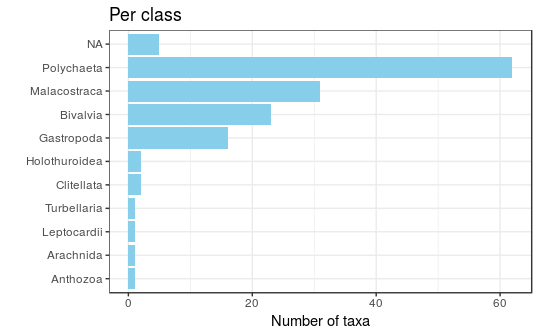

```r
## number of taxa per class
# here, the NAs get sorted to the end (the axis order is reversed, that's why they appear on top). But it's better to have them (barchart from base R, which I used previously, silently drops them) - they are not a mistake and should be present: some taxa have no class at all, others are only identified to an upper taxonomic level.
current.taxa.sand %>%
  count(class, sort = TRUE) %>%
  ggplot(mapping = aes(x = reorder(class, n), y = n)) +
    geom_bar(stat = "identity", fill = "skyblue") +
    coord_flip() +
    labs(title = "Per class", x = "", y = "Number of taxa") +
    theme_bw()
```

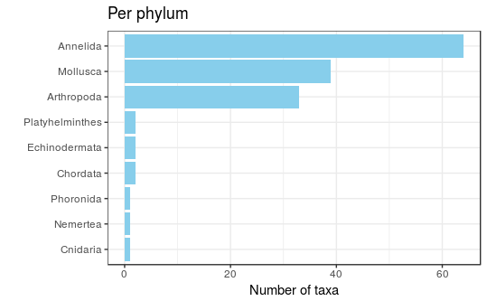

```r
## number of taxa per phylum
current.taxa.sand %>%
  count(phylum, sort = TRUE) %>%
  ggplot(mapping = aes(x = reorder(phylum, n), y = n)) +
    geom_bar(stat = "identity", fill = "skyblue") +
    coord_flip() +
    labs(title = "Per phylum", x = "", y = "Number of taxa") +
    theme_bw()
```

The most commonly used larger taxonomic groups in the literature are not class & phylum, but Polychaeta, Mollusca, Crustacea, and Varia (= all the rest). Adding them requires some data transformation.

```r
# the conditions have to be based on fields that do not contain NAs - or, more precisely, they have to be formulated in a way that DOESN'T return NA as a result of the evaluation. Otherwise the reclassification will result in those groups remaining as NA. This behaviour is caused by the way dplyr and mutate treat NAs; works as I expected in base R, so I didn't notice it before.
current.taxa.sand <- current.taxa.sand %>%
  mutate(group = case_when(
    phylum == "Mollusca" ~ "Mollusca",
    phylum == "Annelida" & class == "Polychaeta" ~ "Polychaeta",
    phylum == "Arthropoda" & subclass %in% c("Eumalacostraca", "Thecostraca") ~ "Crustacea",
    TRUE ~ "Varia"
  ))
current.taxa.sand %>%
  count(group)
```

| group | n |
| --- | --- |
| Crustacea | 32 |
| Mollusca | 39 |
| Polychaeta | 62 |
| Varia | 12 |

Good. Now let’s plot the number of taxa per (common) taxonomic group, and save as file.

```r
plot.nb.taxa.by.group <- current.taxa.sand %>%
  count(group) %>%
  ggplot(mapping = aes(x = reorder(group, n), y = n)) +
    geom_bar(stat = "identity", fill = "skyblue") +
    coord_flip() +
    labs(x = "", y = "Number of taxa") +
    text_size(text.x = rel(1.3), text.y = rel(1.3)) +
    theme_bw()
ggsave(file.path(figures.dir, "nb_taxa_by_tax_group_sand.png"),
       plot.nb.taxa.by.group,
       dpi = 300)
```

**Crustacea** are represented by 24 families.  
**Polychaeta** are represented by 25 families.  
**Mollusca** are represented by 21 families.

The families with the highest number of species are:

```r
lapply(unique(current.taxa.sand$group),
       function(x) {
         current.taxa.sand %>%
           group_by(group) %>%
           count(family) %>%
           filter(group == x) %>%
           arrange(desc(n))
       })
```

| group | family | n |
| --- | --- | --- |
| Mollusca | Cardiidae | 6 |
| Mollusca | Pyramidellidae | 3 |
| Mollusca | Veneridae | 3 |
| Mollusca | Caecidae | 2 |
| Mollusca | Hydrobiidae | 2 |
| Mollusca | Lucinidae | 2 |
| Mollusca | Mactridae | 2 |
| Mollusca | Mytilidae | 2 |
| Mollusca | Nassariidae | 2 |
| Mollusca | Retusidae | 2 |

[output cut: 11 more lines]

| group | family | n |
| --- | --- | --- |
| Varia | NA | 10 |
| Varia | Branchiostomatidae | 1 |
| Varia | Synaptidae | 1 |

| group | family | n |
| --- | --- | --- |
| Polychaeta | Nereididae | 8 |
| Polychaeta | Phyllodocidae | 6 |
| Polychaeta | Syllidae | 6 |
| Polychaeta | Spionidae | 5 |
| Polychaeta | Capitellidae | 3 |
| Polychaeta | Maldanidae | 3 |
| Polychaeta | Nephtyidae | 3 |
| Polychaeta | Terebellidae | 3 |
| Polychaeta | Dorvilleidae | 2 |
| Polychaeta | Eunicidae | 2 |

[output cut: 15 more lines]

| group | family | n |
| --- | --- | --- |
| Crustacea | Bodotriidae | 4 |
| Crustacea | Aoridae | 3 |
| Crustacea | Corophiidae | 3 |
| Crustacea | Cirolanidae | 2 |
| Crustacea | Ampeliscidae | 1 |
| Crustacea | Ampithoidae | 1 |
| Crustacea | Apseudidae | 1 |
| Crustacea | Atylidae | 1 |
| Crustacea | Balanidae | 1 |
| Crustacea | Bathyporeiidae | 1 |

[output cut: 14 more lines]

```
NA
```

NB this is a count of the frequency of occurrence of each family; it would be a real count of the number of species if all taxa were identified to species level. As it is, there are some identified to genus or family level - so this count is only indicative. It really should be checked manually and corrected, if needed.  
Now let’s calculate the contribution of each taxonomic group to the **overall community composition by abundance**.

```r
## helper function to summarize taxonomic group contribution to abundance and biomass
summarize_tax_group_contr <- function(zoo.data, tax.data, key.col, value.col, ...) {
  # zoo.data - long data frame of count/biomass data
  # tax.data - data frame (wide) of taxonomic information on the same species
  # key.col - name of column to be used as key for joining the two data frames
  # value.col - name of column in zoo.data containing the values to be summarized

  value.col <- enquo(value.col)
  group.vars <- quos(...) # allow for multiple grouping variables
  zoo.data %>%
    left_join(tax.data, by = key.col) %>%
    group_by(!!!group.vars) %>%
    summarise(total := sum(!!value.col)) %>%
    mutate(proportion = total / sum(total))
}
zoo.abnd.sand.long %>%
  # exclude these poor larvae again (not that they contribute much, it's < 0.1%, but only to get the same numbers as are already in the text)
  filter(!(species == "Decapoda larvae" | species == "Polychaeta larvae")) %>%
  summarize_tax_group_contr(current.taxa.sand,
                            key.col = "species",
                            value.col = sp_count,
                            group) %>%
  arrange(desc(proportion))
```

| group | total | proportion |
| --- | --- | --- |
| Polychaeta | 7991 | 0.4382232 |
| Mollusca | 4125 | 0.2262133 |
| Varia | 3187 | 0.1747738 |
| Crustacea | 2932 | 0.1607897 |

Now calculate and plot the **contribution of the taxonomic groups to the abundance by station and year**.

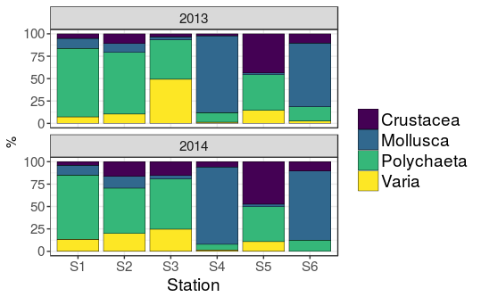

```r
tax.props.st.yr.sand <- zoo.abnd.sand.long %>%
  # exclude the larvae
  filter(!(species == "Decapoda larvae" | species == "Polychaeta larvae")) %>%
  summarize_tax_group_contr(current.taxa.sand,
                            key.col = "species",
                            value.col = sp_count,
                            station, year, group) %>%
  arrange(station, year)
## helper for plotting, because all the repetition is killing me. Don't care if everything within is hardcoded, this is only going to be used here and with this data anyway.
plot_tax_props <- function(tax.props.data, x.labels = NULL, col.palette = "viridis") {

  # get/make x-axis labels (stations)
  if(length(x.labels) > 1) {
    x.labs <- x.labels
  } else {
    x.labs <- paste0(x.labels, 1:length(unique(tax.props.data$station)))
  }
  ggplot(tax.props.data) +
    geom_bar(mapping = aes(x = station,
                           y = proportion * 100,
                           fill = group),
             color = "black", size = 0.15,
             stat = "identity", position = "stack", inherit.aes = TRUE) +
    scale_fill_viridis(option = col.palette, discrete = TRUE, name = "") +
    scale_x_discrete(labels = x.labs) +
    labs(x = "Station", y = "%") +
    theme_bw()
}
(plot.tax.props.st.yr.sand <- plot_tax_props(tax.props.st.yr.sand, x.labels = "S",col.palette = "viridis") +
    facet_wrap(~year, nrow = 2) +
    text_size(text.x = rel(1.3), text.y = rel(1.3), title.x = rel(1.3), legend.text = rel(1.3), strip.x = rel(1.3))
)
## save as file
ggsave(file.path(figures.dir, "tax_gr_props_st_yr_sand.png"),
       plot.tax.props.st.yr.sand,
       dpi = 300)
```

Check and plot the species which contribute the most to the abundance at each station.

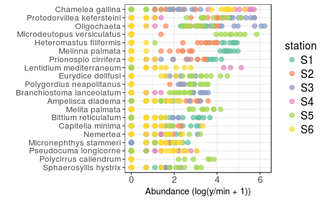

```r
## helper function to get the top n species with the highest abundance/biomass overall
get_top_sp <- function(zoo.data, nb.sp = 20) {
  # zoo.data - count/biomass data - wide format!
  # nb.sp - number of top-contributing species to select
  zoo.data.long <- zoo.data %>%
    gather(key = species, value = sp_count, -c(station:replicate))

  # find the top n species in the dataset
  top.n <- zoo.data.long %>%
    group_by(species) %>%
    summarise(total_count = sum(sp_count)) %>%
    arrange(desc(total_count)) %>%
    top_n(nb.sp)

  # subset their actual abundance/biomass at each station from the original (wide) dataset (to keep the order; I'm too lazy to figure out how to best rearrange the long data itself)
  top.n.st <- zoo.data %>%
    select(habitat, station, top.n$species) %>%
    gather(key = species, value = sp_count, -c(station, habitat)) %>%
    mutate(species = factor(species, levels = unique(species))) # convert species to factor to keep this order for plotting
  return(top.n.st)
}
top20.counts.sand.st <- get_top_sp(zoo.abnd.sand, nb.sp = 20)
## another helper for the plot, because I'm sick of writing all these parameters over and over - not that it ended up being that much more concise, but ok, teachable moment
plot_top_n <- function(top.n.sp.data, mapping, labs.legend, lab.y, palette) {
  # top.n.sp.data - data frame (long) of top species' counts/biomasses at the different stations
  # mapping - mappings of the aesthetics

  ggplot(top.n.sp.data, mapping) +
    geom_point(size = 2.5, alpha = 0.75) + # make points larger & partially transparent
    scale_color_brewer(palette = palette,  labels = labs.legend) +
    ylab(lab.y) +
    coord_flip() +
    theme_bw()
}
plot.most.abnd.sp.sand <- plot_top_n(top20.counts.sand.st,
                                     aes(x = species, y = log_y_min(sp_count),
                                         colour = station),
                                     labs.legend = paste0("S", as.numeric(unique(top20.counts.sand.st$station))),
                                     lab.y = "Abundance (log(y/min + 1))",
                                     palette = "Set2"
                                     )
(plot.most.abnd.sp.sand <- plot.most.abnd.sp.sand  +
    text_size(text.x = rel(1.3), text.y = rel(1.15), legend.text = rel(1.2), legend.title = rel(1.2)) +
    scale_x_discrete(name = "", limits = rev(levels(top20.counts.sand.st$species)))
)
## save as file
ggsave(file.path(figures.dir, "most_abnd_sp_st_sand.png"),
       plot.most.abnd.sp.sand,
       dpi = 300)
```

Now let’s calculate the same way the **overall community composition by biomass**.

```r
zoo.biomass.sand.long %>%
  # exclude the larvae
  filter(!(species == "Decapoda larvae" | species == "Polychaeta larvae")) %>%
  summarize_tax_group_contr(current.taxa.sand,
                            key.col = "species",
                            value.col = sp_biomass,
                            group) %>%
  arrange(desc(proportion))
```

| group | total | proportion |
| --- | --- | --- |
| Mollusca | 1060.6607 | 0.971368078 |
| Polychaeta | 15.0401 | 0.013773936 |
| Varia | 11.4037 | 0.010443670 |
| Crustacea | 4.8201 | 0.004414316 |

Then calculate and plot the **contribution of the taxonomic groups to the biomass by station and year**.

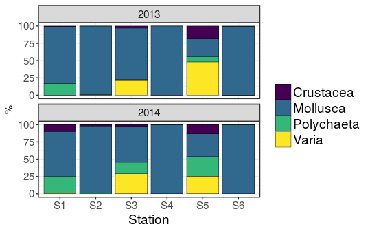

```r
tax.props.biomass.st.yr.sand <- zoo.biomass.sand.long %>%
  # exclude the larvae
  filter(!(species == "Decapoda larvae" | species == "Polychaeta larvae")) %>%
  summarize_tax_group_contr(current.taxa.sand,
                            key.col = "species",
                            value.col = sp_biomass,
                            station, year, group) %>%
  arrange(station, year)
# plot this
(plot.tax.props.biomass.st.yr.sand <- plot_tax_props(tax.props.biomass.st.yr.sand, x.labels = "S", col.palette = "viridis") +
    facet_wrap(~year, nrow = 2) +
    text_size(text.x = rel(1.3), text.y = rel(1.3), title.x = rel(1.3), legend.text = rel(1.3), strip.x = rel(1.3))
)
## save as file
ggsave(file.path(figures.dir, "tax_gr_props_biomass_st_yr_sand.png"),
       plot.tax.props.biomass.st.yr.sand,
       dpi = 300)
```

Now, for the text itself, combine the proportions of the abundance and the biomass in one single plot.

```
Saving 15 x 7.01 cm image
```

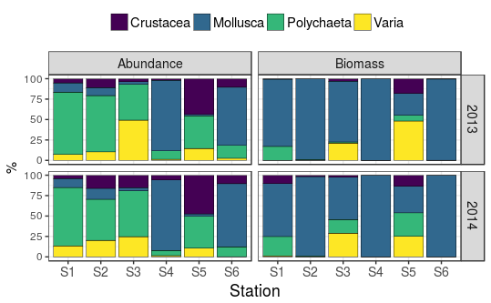

```r
## first, combine the proportional abundance and biomass tibbles into a single common (long) one
tax.props.sand.all <- full_join(tax.props.st.yr.sand,
                                tax.props.biomass.st.yr.sand,
                                by = c("station", "year", "group")) %>%
  select(-starts_with("total")) %>%
  gather(key = variable, value = proportion, -station, -year, -group) %>%
  mutate(variable = case_when(variable == "proportion.x" ~ "Abundance",
                              variable == "proportion.y" ~ "Biomass"))
(plot.composite.tax.gr.props.sand <- plot_tax_props(tax.props.sand.all, x.labels = "S") +
    facet_grid(year ~ variable) +
    theme(legend.position = "top", legend.key.size = unit(0.5, "cm")) +
    text_size(text.x = rel(1.2), text.y = rel(1), title.x = rel(1.2), legend.text = rel(1), strip.x = rel(1.2), strip.y = rel(1.2))
)
ggsave(file.path(figures.dir, "tax_gr_props_sand_composite.png"),
       plot.composite.tax.gr.props.sand,
       dpi = 300, width = 15, units = "cm")
```

Back to the biomass: check and plot the species which contribute the most to the biomass at each station.

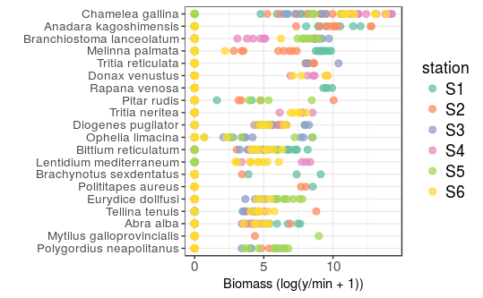

```r
## calculate the total biomass counts by species, then select the 20 with the highest biomass
top20.biomass.sand.st <- get_top_sp(zoo.biomass.sand, nb.sp = 20)
## plot them
plot.highest.biomass.sp.sand <- plot_top_n(top20.biomass.sand.st,
                                     aes(x = species, y = log_y_min(sp_count),
                                         colour = station),
                                     labs.legend = paste0("S", as.numeric(unique(top20.biomass.sand.st$station))),
                                     lab.y = "Biomass (log(y/min + 1))",
                                     palette = "Set2"
                                     )
(plot.highest.biomass.sp.sand <- plot.highest.biomass.sp.sand  +
    text_size(text.x = rel(1.3), text.y = rel(1.15), legend.text = rel(1.2), legend.title = rel(1.2)) +
    scale_x_discrete(name = "", limits = rev(levels(top20.biomass.sand.st$species)))
)

## save as file
ggsave(file.path(figures.dir, "highest_biomass_sp_st_sand.png"),
       plot.highest.biomass.sp.sand,
       dpi = 300)
```

#### Macrozoobenthic communities in the seagrasses of Burgas Bay (2013-2014)

Now we’ll do all of this again, for the seagrass communities. Import the zoobenthic abundance & biomass data.

```r
## import & check the abundance data. Dimensions should be 32 x 205 (5 metadata + 200 species columns); all species columns should be numeric.
(zoo.abnd.zostera <- import_zoo_data(data.dir = data.dir,
                                     zoo.data = "zoo_abnd_zostera_orig.csv",
                                     meta.labels = c("station", "month", "year", "habitat", "replicate")))
```

|  | station | month | year | habitat | replicate | Abra alba | Abra prismatica | Abra segmentum | Abra sp. | Acanthocardia tuberculata | Acari | Actiniaria | Alitta succinea | Ampelisca diadema | Ampharetidae | Amphibalanus improvisus | Amphipoda | Amphitritides gracilis | Ampithoe sp. | Anadara kagoshimensis | Aonides paucibranchiata | Apherusa bispinosa | Apseudopsis ostroumovi | Aricidea claudiae | Bathyporeia guilliamsoniana | Bittium reticulatum | Bivalvia undet. | Bodotria arenosa | Brachynotus sexdentatus | … |
| --- | --- | --- | --- | --- | --- | --- | --- | --- | --- | --- | --- | --- | --- | --- | --- | --- | --- | --- | --- | --- | --- | --- | --- | --- | --- | --- | --- | --- | --- | --- |
| 1 | Gradina | 6 | 2013 | Z | a | 1 | 0 | 0 | 0 | 0 | 0 | 0 | 0 | 4 | 0 | 1 | 0 | 0 | 0 | 0 | 0 | 0 | 2 | 0 | 0 | 353 | 0 | 0 | 0 | … |
| 2 | Gradina | 6 | 2013 | Z | b | 3 | 0 | 0 | 0 | 0 | 0 | 0 | 0 | 1 | 0 | 0 | 0 | 0 | 1 | 0 | 0 | 0 | 2 | 0 | 0 | 429 | 0 | 0 | 0 | … |
| 3 | Gradina | 6 | 2013 | Z | c | 0 | 0 | 0 | 0 | 0 | 0 | 0 | 0 | 2 | 0 | 0 | 0 | 0 | 0 | 0 | 0 | 0 | 1 | 0 | 0 | 125 | 0 | 0 | 1 | … |
| 4 | Gradina | 6 | 2013 | Z | d | 1 | 0 | 0 | 0 | 0 | 0 | 0 | 0 | 1 | 0 | 1 | 0 | 0 | 2 | 0 | 0 | 0 | 4 | 0 | 0 | 301 | 0 | 0 | 0 | … |
| 5 | Gradina | 7 | 2014 | Z | a | 1 | 0 | 0 | 0 | 0 | 0 | 0 | 0 | 58 | 0 | 0 | 0 | 0 | 0 | 0 | 0 | 1 | 6 | 0 | 0 | 11 | 0 | 0 | 0 | … |
| 6 | Gradina | 7 | 2014 | Z | b | 0 | 0 | 0 | 0 | 0 | 0 | 0 | 0 | 45 | 0 | 0 | 0 | 0 | 0 | 0 | 0 | 0 | 8 | 0 | 0 | 216 | 0 | 0 | 0 | … |
| 7 | Gradina | 7 | 2014 | Z | c | 0 | 0 | 0 | 0 | 0 | 0 | 0 | 0 | 21 | 0 | 0 | 0 | 0 | 1 | 0 | 0 | 0 | 8 | 0 | 0 | 406 | 0 | 0 | 0 | … |
| 8 | Gradina | 7 | 2014 | Z | d | 0 | 0 | 0 | 0 | 0 | 0 | 0 | 0 | 64 | 0 | 0 | 0 | 0 | 0 | 0 | 0 | 0 | 0 | 0 | 0 | 66 | 0 | 0 | 0 | … |
| 9 | Otmanli | 6 | 2013 | Z | a | 13 | 0 | 0 | 0 | 0 | 0 | 0 | 0 | 0 | 0 | 3 | 0 | 0 | 0 | 0 | 0 | 0 | 0 | 0 | 0 | 28 | 0 | 0 | 0 | … |
| 10 | Otmanli | 6 | 2013 | Z | b | 6 | 0 | 0 | 0 | 0 | 0 | 0 | 0 | 1 | 0 | 1 | 0 | 0 | 0 | 0 | 0 | 0 | 0 | 0 | 0 | 39 | 0 | 0 | 0 | … |

[output cut: 22 more lines]

Convert the month and year back to numeric (they remained as character during import); then arrange the data frame - by station (first converting to factor), then year and month.

```r
(zoo.abnd.zostera <- zoo.abnd.zostera %>%
   mutate(year = as.numeric(year),
          month = as.numeric(month),
          station = factor(station, levels = c("Poda", "Otmanli", "Vromos", "Gradina", "Ropotamo"))) %>%
   arrange(station, year, month))
```

| station | month | year | habitat | replicate | Abra alba | Abra prismatica | Abra segmentum | Abra sp. | Acanthocardia tuberculata | Acari | Actiniaria | Alitta succinea | Ampelisca diadema | Ampharetidae | Amphibalanus improvisus | Amphipoda | Amphitritides gracilis | Ampithoe sp. | Anadara kagoshimensis | Aonides paucibranchiata | Apherusa bispinosa | Apseudopsis ostroumovi | Aricidea claudiae | Bathyporeia guilliamsoniana | Bittium reticulatum | Bivalvia undet. | Bodotria arenosa | Brachynotus sexdentatus | Brachystomia scalaris | … |
| --- | --- | --- | --- | --- | --- | --- | --- | --- | --- | --- | --- | --- | --- | --- | --- | --- | --- | --- | --- | --- | --- | --- | --- | --- | --- | --- | --- | --- | --- | --- |
| Poda | 6 | 2013 | Z | a | 13 | 0 | 0 | 0 | 0 | 0 | 1 | 15 | 13 | 0 | 2 | 0 | 0 | 0 | 0 | 0 | 0 | 0 | 0 | 0 | 0 | 0 | 0 | 0 | 0 | … |
| Poda | 6 | 2013 | Z | b | 8 | 0 | 0 | 0 | 0 | 0 | 0 | 7 | 4 | 0 | 20 | 0 | 0 | 0 | 0 | 0 | 0 | 0 | 0 | 0 | 10 | 0 | 0 | 1 | 0 | … |
| Poda | 6 | 2013 | Z | c | 4 | 0 | 0 | 0 | 0 | 0 | 0 | 6 | 25 | 0 | 2 | 0 | 0 | 0 | 0 | 0 | 0 | 0 | 0 | 0 | 4 | 0 | 0 | 0 | 0 | … |
| Poda | 6 | 2013 | Z | d | 5 | 0 | 0 | 0 | 0 | 0 | 0 | 17 | 14 | 0 | 1 | 0 | 0 | 0 | 0 | 0 | 0 | 0 | 0 | 0 | 6 | 0 | 0 | 0 | 0 | … |
| Poda | 7 | 2014 | Z | a | 3 | 0 | 0 | 0 | 0 | 0 | 0 | 0 | 9 | 0 | 3 | 0 | 0 | 0 | 0 | 0 | 0 | 0 | 0 | 0 | 49 | 0 | 0 | 0 | 0 | … |
| Poda | 7 | 2014 | Z | b | 5 | 0 | 0 | 0 | 0 | 0 | 0 | 4 | 5 | 0 | 4 | 0 | 0 | 0 | 0 | 0 | 0 | 0 | 0 | 0 | 177 | 0 | 0 | 0 | 0 | … |
| Poda | 7 | 2014 | Z | c | 9 | 0 | 0 | 0 | 0 | 0 | 0 | 6 | 4 | 0 | 7 | 0 | 0 | 0 | 1 | 0 | 0 | 0 | 0 | 0 | 143 | 0 | 0 | 0 | 0 | … |
| Poda | 7 | 2014 | Z | d | 2 | 0 | 0 | 0 | 0 | 0 | 0 | 2 | 11 | 0 | 5 | 0 | 0 | 0 | 0 | 0 | 0 | 0 | 0 | 0 | 65 | 0 | 0 | 0 | 0 | … |
| Otmanli | 6 | 2013 | Z | a | 13 | 0 | 0 | 0 | 0 | 0 | 0 | 0 | 0 | 0 | 3 | 0 | 0 | 0 | 0 | 0 | 0 | 0 | 0 | 0 | 28 | 0 | 0 | 0 | 0 | … |
| Otmanli | 6 | 2013 | Z | b | 6 | 0 | 0 | 0 | 0 | 0 | 0 | 0 | 1 | 0 | 1 | 0 | 0 | 0 | 0 | 0 | 0 | 0 | 0 | 0 | 39 | 0 | 0 | 0 | 0 | … |

[output cut: 22 more lines]

Now on to the biomass!

```r
## import & check out the biomass data.
(zoo.biomass.zostera <- import_zoo_data(data.dir = data.dir,
                                        zoo.data = "zoo_biomass_zostera_orig.csv",
                                        meta.labels = c("station", "month", "year", "habitat", "replicate")))
```

|  | station | month | year | habitat | replicate | Abra alba | Abra prismatica | Abra segmentum | Abra sp. | Acanthocardia tuberculata | Acari | Actiniaria | Alitta succinea | Ampelisca diadema | Ampharetidae | Amphibalanus improvisus | Amphipoda | Amphitritides gracilis | Ampithoe sp. | Anadara kagoshimensis | Aonides paucibranchiata | Apherusa bispinosa | Apseudopsis ostroumovi | Aricidea claudiae | Bathyporeia guilliamsoniana | Bittium reticulatum | Bivalvia undet. | Bodotria arenosa | Brachynotus sexdentatus | … |
| --- | --- | --- | --- | --- | --- | --- | --- | --- | --- | --- | --- | --- | --- | --- | --- | --- | --- | --- | --- | --- | --- | --- | --- | --- | --- | --- | --- | --- | --- | --- |
| 1 | Gradina | 6 | 2013 | Z | a | 0.0034 | 0 | 0 | 0e+00 | 0 | 0 | 0.0000 | 0.0000 | 0.0004 | 0 | 0.0031 | 0 | 0 | 0e+00 | 0.0000 | 0 | 0e+00 | 0.0015 | 0 | 0 | 2.7941 | 0 | 0 | 0.0000 | … |
| 2 | Gradina | 6 | 2013 | Z | b | 0.0056 | 0 | 0 | 0e+00 | 0 | 0 | 0.0000 | 0.0000 | 0.0001 | 0 | 0.0000 | 0 | 0 | 1e-04 | 0.0000 | 0 | 0e+00 | 0.0004 | 0 | 0 | 3.5654 | 0 | 0 | 0.0000 | … |
| 3 | Gradina | 6 | 2013 | Z | c | 0.0000 | 0 | 0 | 0e+00 | 0 | 0 | 0.0000 | 0.0000 | 0.0002 | 0 | 0.0000 | 0 | 0 | 0e+00 | 0.0000 | 0 | 0e+00 | 0.0002 | 0 | 0 | 1.0254 | 0 | 0 | 0.3018 | … |
| 4 | Gradina | 6 | 2013 | Z | d | 0.0034 | 0 | 0 | 0e+00 | 0 | 0 | 0.0000 | 0.0000 | 0.0001 | 0 | 0.0035 | 0 | 0 | 1e-04 | 0.0000 | 0 | 0e+00 | 0.0008 | 0 | 0 | 2.0744 | 0 | 0 | 0.0000 | … |
| 5 | Gradina | 7 | 2014 | Z | a | 0.0014 | 0 | 0 | 0e+00 | 0 | 0 | 0.0000 | 0.0000 | 0.0455 | 0 | 0.0000 | 0 | 0 | 0e+00 | 0.0000 | 0 | 3e-04 | 0.0040 | 0 | 0 | 0.1272 | 0 | 0 | 0.0000 | … |
| 6 | Gradina | 7 | 2014 | Z | b | 0.0000 | 0 | 0 | 0e+00 | 0 | 0 | 0.0000 | 0.0000 | 0.0509 | 0 | 0.0000 | 0 | 0 | 0e+00 | 0.0000 | 0 | 0e+00 | 0.0035 | 0 | 0 | 0.4819 | 0 | 0 | 0.0000 | … |
| 7 | Gradina | 7 | 2014 | Z | c | 0.0000 | 0 | 0 | 0e+00 | 0 | 0 | 0.0000 | 0.0000 | 0.0134 | 0 | 0.0000 | 0 | 0 | 1e-04 | 0.0000 | 0 | 0e+00 | 0.0029 | 0 | 0 | 0.7492 | 0 | 0 | 0.0000 | … |
| 8 | Gradina | 7 | 2014 | Z | d | 0.0000 | 0 | 0 | 0e+00 | 0 | 0 | 0.0000 | 0.0000 | 0.0596 | 0 | 0.0000 | 0 | 0 | 0e+00 | 0.0000 | 0 | 0e+00 | 0.0000 | 0 | 0 | 0.5110 | 0 | 0 | 0.0000 | … |
| 9 | Otmanli | 6 | 2013 | Z | a | 0.0226 | 0 | 0 | 0e+00 | 0 | 0 | 0.0000 | 0.0000 | 0.0000 | 0 | 0.0353 | 0 | 0 | 0e+00 | 0.0000 | 0 | 0e+00 | 0.0000 | 0 | 0 | 0.2333 | 0 | 0 | 0.0000 | … |
| 10 | Otmanli | 6 | 2013 | Z | b | 0.0178 | 0 | 0 | 0e+00 | 0 | 0 | 0.0000 | 0.0000 | 0.0001 | 0 | 0.0121 | 0 | 0 | 0e+00 | 0.0000 | 0 | 0e+00 | 0.0000 | 0 | 0 | 0.3117 | 0 | 0 | 0.0000 | … |

[output cut: 22 more lines]

```r
# same expected structure as the abundance
```

```r
(zoo.biomass.zostera <- zoo.biomass.zostera %>%
   mutate(year = as.numeric(year),
          month = as.numeric(month),
          station = factor(station, levels = c("Poda", "Otmanli", "Vromos", "Gradina", "Ropotamo"))) %>%
   arrange(station, year, month))
```

| station | month | year | habitat | replicate | Abra alba | Abra prismatica | Abra segmentum | Abra sp. | Acanthocardia tuberculata | Acari | Actiniaria | Alitta succinea | Ampelisca diadema | Ampharetidae | Amphibalanus improvisus | Amphipoda | Amphitritides gracilis | Ampithoe sp. | Anadara kagoshimensis | Aonides paucibranchiata | Apherusa bispinosa | Apseudopsis ostroumovi | Aricidea claudiae | Bathyporeia guilliamsoniana | Bittium reticulatum | Bivalvia undet. | Bodotria arenosa | Brachynotus sexdentatus | Brachystomia scalaris | … |
| --- | --- | --- | --- | --- | --- | --- | --- | --- | --- | --- | --- | --- | --- | --- | --- | --- | --- | --- | --- | --- | --- | --- | --- | --- | --- | --- | --- | --- | --- | --- |
| Poda | 6 | 2013 | Z | a | 0.1829 | 0 | 0 | 0e+00 | 0 | 0 | 0.0036 | 0.0038 | 0.0213 | 0 | 0.0015 | 0 | 0 | 0e+00 | 0.0000 | 0 | 0e+00 | 0.0000 | 0 | 0 | 0.0000 | 0 | 0 | 0.0000 | 0 | … |
| Poda | 6 | 2013 | Z | b | 0.3158 | 0 | 0 | 0e+00 | 0 | 0 | 0.0000 | 0.0012 | 0.0011 | 0 | 0.0320 | 0 | 0 | 0e+00 | 0.0000 | 0 | 0e+00 | 0.0000 | 0 | 0 | 0.1216 | 0 | 0 | 0.5183 | 0 | … |
| Poda | 6 | 2013 | Z | c | 0.0062 | 0 | 0 | 0e+00 | 0 | 0 | 0.0000 | 0.0018 | 0.0179 | 0 | 0.0022 | 0 | 0 | 0e+00 | 0.0000 | 0 | 0e+00 | 0.0000 | 0 | 0 | 0.0069 | 0 | 0 | 0.0000 | 0 | … |
| Poda | 6 | 2013 | Z | d | 0.0438 | 0 | 0 | 0e+00 | 0 | 0 | 0.0000 | 0.0102 | 0.0019 | 0 | 0.0508 | 0 | 0 | 0e+00 | 0.0000 | 0 | 0e+00 | 0.0000 | 0 | 0 | 0.1724 | 0 | 0 | 0.0000 | 0 | … |
| Poda | 7 | 2014 | Z | a | 0.1181 | 0 | 0 | 0e+00 | 0 | 0 | 0.0000 | 0.0000 | 0.0176 | 0 | 0.0064 | 0 | 0 | 0e+00 | 0.0000 | 0 | 0e+00 | 0.0000 | 0 | 0 | 0.5945 | 0 | 0 | 0.0000 | 0 | … |
| Poda | 7 | 2014 | Z | b | 0.3482 | 0 | 0 | 0e+00 | 0 | 0 | 0.0000 | 0.0049 | 0.0077 | 0 | 0.0041 | 0 | 0 | 0e+00 | 0.0000 | 0 | 0e+00 | 0.0000 | 0 | 0 | 1.5586 | 0 | 0 | 0.0000 | 0 | … |
| Poda | 7 | 2014 | Z | c | 0.1333 | 0 | 0 | 0e+00 | 0 | 0 | 0.0000 | 0.0023 | 0.0066 | 0 | 0.0418 | 0 | 0 | 0e+00 | 0.5544 | 0 | 0e+00 | 0.0000 | 0 | 0 | 1.6292 | 0 | 0 | 0.0000 | 0 | … |
| Poda | 7 | 2014 | Z | d | 0.0308 | 0 | 0 | 0e+00 | 0 | 0 | 0.0000 | 0.0001 | 0.0103 | 0 | 0.0063 | 0 | 0 | 0e+00 | 0.0000 | 0 | 0e+00 | 0.0000 | 0 | 0 | 0.6858 | 0 | 0 | 0.0000 | 0 | … |
| Otmanli | 6 | 2013 | Z | a | 0.0226 | 0 | 0 | 0e+00 | 0 | 0 | 0.0000 | 0.0000 | 0.0000 | 0 | 0.0353 | 0 | 0 | 0e+00 | 0.0000 | 0 | 0e+00 | 0.0000 | 0 | 0 | 0.2333 | 0 | 0 | 0.0000 | 0 | … |
| Otmanli | 6 | 2013 | Z | b | 0.0178 | 0 | 0 | 0e+00 | 0 | 0 | 0.0000 | 0.0000 | 0.0001 | 0 | 0.0121 | 0 | 0 | 0e+00 | 0.0000 | 0 | 0e+00 | 0.0000 | 0 | 0 | 0.3117 | 0 | 0 | 0.0000 | 0 | … |

[output cut: 22 more lines]

Goody! To be on the safe side, save the cleaned abundance & biomass data frames.

```r
write_csv(zoo.abnd.zostera,
          path = file.path(save.dir, "abnd_zostera_orig_clean.csv"))
write_csv(zoo.biomass.zostera,
          path = file.path(save.dir, "biomass_zostera_orig_clean.csv"))
```

On with the cleaning.  
First we’ll remove the species that are absent from the current dataset - don’t appear at these particular stations & samplings, etc. This will simplify later analyses, especially the more complex ones that require a lot of time.

```r
# long data is immensely easier to manipulate within the tidyverse, so we'll do some back-and-forth conversions
(zoo.abnd.zostera <- zoo.abnd.zostera %>%
  gather(key = species, value = sp_count, -c(station:replicate)) %>%
  group_by(species) %>%
  filter(sp_count > 0) %>%
  spread(species, sp_count, fill = 0) %>%
  arrange(station, year, replicate))
```

| station | month | year | habitat | replicate | Abra alba | Abra sp. | Actiniaria | Alitta succinea | Ampelisca diadema | Amphibalanus improvisus | Ampithoe sp. | Anadara kagoshimensis | Apherusa bispinosa | Apseudopsis ostroumovi | Bittium reticulatum | Brachynotus sexdentatus | Capitella capitata | Capitella minima | Chamelea gallina | Chironomidae larvae | Cumella limicola | Cumella pygmaea | Cytharella costulata | Diogenes pugilator | Eteone flava | Eunice vittata | Eurydice dollfusi | Exogone naidina | Gastrosaccus sanctus | … |
| --- | --- | --- | --- | --- | --- | --- | --- | --- | --- | --- | --- | --- | --- | --- | --- | --- | --- | --- | --- | --- | --- | --- | --- | --- | --- | --- | --- | --- | --- | --- |
| Poda | 6 | 2013 | Z | a | 13 | 0 | 1 | 15 | 13 | 2 | 0 | 0 | 0 | 0 | 0 | 0 | 0 | 169 | 0 | 0 | 0 | 0 | 0 | 0 | 0 | 0 | 0 | 0 | 0 | … |
| Poda | 6 | 2013 | Z | b | 8 | 0 | 0 | 7 | 4 | 20 | 0 | 0 | 0 | 0 | 10 | 1 | 0 | 113 | 0 | 0 | 0 | 0 | 0 | 1 | 0 | 2 | 0 | 0 | 0 | … |
| Poda | 6 | 2013 | Z | c | 4 | 0 | 0 | 6 | 25 | 2 | 0 | 0 | 0 | 0 | 4 | 0 | 0 | 107 | 0 | 0 | 0 | 0 | 0 | 1 | 0 | 0 | 0 | 0 | 0 | … |
| Poda | 6 | 2013 | Z | d | 5 | 0 | 0 | 17 | 14 | 1 | 0 | 0 | 0 | 0 | 6 | 0 | 0 | 81 | 0 | 0 | 0 | 0 | 0 | 0 | 0 | 0 | 0 | 0 | 0 | … |
| Poda | 7 | 2014 | Z | a | 3 | 0 | 0 | 0 | 9 | 3 | 0 | 0 | 0 | 0 | 49 | 0 | 0 | 3 | 0 | 0 | 0 | 0 | 0 | 0 | 0 | 0 | 0 | 0 | 0 | … |
| Poda | 7 | 2014 | Z | b | 5 | 0 | 0 | 4 | 5 | 4 | 0 | 0 | 0 | 0 | 177 | 0 | 1 | 3 | 0 | 0 | 0 | 0 | 0 | 0 | 0 | 0 | 0 | 0 | 0 | … |
| Poda | 7 | 2014 | Z | c | 9 | 0 | 0 | 6 | 4 | 7 | 0 | 1 | 0 | 0 | 143 | 0 | 0 | 3 | 0 | 0 | 0 | 0 | 0 | 0 | 0 | 0 | 0 | 0 | 0 | … |
| Poda | 7 | 2014 | Z | d | 2 | 0 | 0 | 2 | 11 | 5 | 0 | 0 | 0 | 0 | 65 | 0 | 0 | 1 | 0 | 0 | 0 | 0 | 0 | 0 | 0 | 0 | 0 | 0 | 0 | … |
| Otmanli | 6 | 2013 | Z | a | 13 | 0 | 0 | 0 | 0 | 3 | 0 | 0 | 0 | 0 | 28 | 0 | 0 | 76 | 0 | 0 | 0 | 0 | 0 | 1 | 0 | 0 | 0 | 0 | 0 | … |
| Otmanli | 6 | 2013 | Z | b | 6 | 0 | 0 | 0 | 1 | 1 | 0 | 0 | 0 | 0 | 39 | 0 | 0 | 58 | 0 | 0 | 0 | 0 | 1 | 1 | 0 | 1 | 0 | 0 | 0 | … |

[output cut: 22 more lines]

```r
(zoo.biomass.zostera <- zoo.biomass.zostera %>%
  gather(key = species, value = sp_biomass, -c(station:replicate)) %>%
  group_by(species) %>%
  filter(sp_biomass > 0) %>%
  spread(species, sp_biomass, fill = 0) %>%
  arrange(station, year, replicate))
```

| station | month | year | habitat | replicate | Abra alba | Abra sp. | Actiniaria | Alitta succinea | Ampelisca diadema | Amphibalanus improvisus | Ampithoe sp. | Anadara kagoshimensis | Apherusa bispinosa | Apseudopsis ostroumovi | Bittium reticulatum | Brachynotus sexdentatus | Capitella capitata | Capitella minima | Chamelea gallina | Chironomidae larvae | Cumella limicola | Cumella pygmaea | Cytharella costulata | Diogenes pugilator | Eteone flava | Eunice vittata | Eurydice dollfusi | Exogone naidina | Gastrosaccus sanctus | … |
| --- | --- | --- | --- | --- | --- | --- | --- | --- | --- | --- | --- | --- | --- | --- | --- | --- | --- | --- | --- | --- | --- | --- | --- | --- | --- | --- | --- | --- | --- | --- |
| Poda | 6 | 2013 | Z | a | 0.1829 | 0e+00 | 0.0036 | 0.0038 | 0.0213 | 0.0015 | 0e+00 | 0.0000 | 0e+00 | 0.0000 | 0.0000 | 0.0000 | 0.0000 | 0.0393 | 0.0000 | 0e+00 | 0.0000 | 0e+00 | 0.0000 | 0.0000 | 0e+00 | 0.0000 | 0.0000 | 0e+00 | 0e+00 | … |
| Poda | 6 | 2013 | Z | b | 0.3158 | 0e+00 | 0.0000 | 0.0012 | 0.0011 | 0.0320 | 0e+00 | 0.0000 | 0e+00 | 0.0000 | 0.1216 | 0.5183 | 0.0000 | 0.0226 | 0.0000 | 0e+00 | 0.0000 | 0e+00 | 0.0000 | 0.0003 | 0e+00 | 0.0021 | 0.0000 | 0e+00 | 0e+00 | … |
| Poda | 6 | 2013 | Z | c | 0.0062 | 0e+00 | 0.0000 | 0.0018 | 0.0179 | 0.0022 | 0e+00 | 0.0000 | 0e+00 | 0.0000 | 0.0069 | 0.0000 | 0.0000 | 0.0064 | 0.0000 | 0e+00 | 0.0000 | 0e+00 | 0.0000 | 0.1418 | 0e+00 | 0.0000 | 0.0000 | 0e+00 | 0e+00 | … |
| Poda | 6 | 2013 | Z | d | 0.0438 | 0e+00 | 0.0000 | 0.0102 | 0.0019 | 0.0508 | 0e+00 | 0.0000 | 0e+00 | 0.0000 | 0.1724 | 0.0000 | 0.0000 | 0.0083 | 0.0000 | 0e+00 | 0.0000 | 0e+00 | 0.0000 | 0.0000 | 0e+00 | 0.0000 | 0.0000 | 0e+00 | 0e+00 | … |
| Poda | 7 | 2014 | Z | a | 0.1181 | 0e+00 | 0.0000 | 0.0000 | 0.0176 | 0.0064 | 0e+00 | 0.0000 | 0e+00 | 0.0000 | 0.5945 | 0.0000 | 0.0000 | 0.0002 | 0.0000 | 0e+00 | 0.0000 | 0e+00 | 0.0000 | 0.0000 | 0e+00 | 0.0000 | 0.0000 | 0e+00 | 0e+00 | … |
| Poda | 7 | 2014 | Z | b | 0.3482 | 0e+00 | 0.0000 | 0.0049 | 0.0077 | 0.0041 | 0e+00 | 0.0000 | 0e+00 | 0.0000 | 1.5586 | 0.0000 | 0.0001 | 0.0001 | 0.0000 | 0e+00 | 0.0000 | 0e+00 | 0.0000 | 0.0000 | 0e+00 | 0.0000 | 0.0000 | 0e+00 | 0e+00 | … |
| Poda | 7 | 2014 | Z | c | 0.1333 | 0e+00 | 0.0000 | 0.0023 | 0.0066 | 0.0418 | 0e+00 | 0.5544 | 0e+00 | 0.0000 | 1.6292 | 0.0000 | 0.0000 | 0.0001 | 0.0000 | 0e+00 | 0.0000 | 0e+00 | 0.0000 | 0.0000 | 0e+00 | 0.0000 | 0.0000 | 0e+00 | 0e+00 | … |
| Poda | 7 | 2014 | Z | d | 0.0308 | 0e+00 | 0.0000 | 0.0001 | 0.0103 | 0.0063 | 0e+00 | 0.0000 | 0e+00 | 0.0000 | 0.6858 | 0.0000 | 0.0000 | 0.0001 | 0.0000 | 0e+00 | 0.0000 | 0e+00 | 0.0000 | 0.0000 | 0e+00 | 0.0000 | 0.0000 | 0e+00 | 0e+00 | … |
| Otmanli | 6 | 2013 | Z | a | 0.0226 | 0e+00 | 0.0000 | 0.0000 | 0.0000 | 0.0353 | 0e+00 | 0.0000 | 0e+00 | 0.0000 | 0.2333 | 0.0000 | 0.0000 | 0.0092 | 0.0000 | 0e+00 | 0.0000 | 0e+00 | 0.0000 | 0.0028 | 0e+00 | 0.0000 | 0.0000 | 0e+00 | 0e+00 | … |
| Otmanli | 6 | 2013 | Z | b | 0.0178 | 0e+00 | 0.0000 | 0.0000 | 0.0001 | 0.0121 | 0e+00 | 0.0000 | 0e+00 | 0.0000 | 0.3117 | 0.0000 | 0.0000 | 0.0116 | 0.0000 | 0e+00 | 0.0000 | 0e+00 | 0.0098 | 0.2506 | 0e+00 | 0.0022 | 0.0000 | 0e+00 | 0e+00 | … |

[output cut: 22 more lines]

Ready to proceed with the community structure & composition analyses!

1. Summary statistics for the community structure & composition  
   Careful with the multilplication factor when going to ind.m<sup>-2</sup> & g.m<sup>-2</sup>: seagrass communities were sampled with corers, and the sampling surface is different than in sand communities.
- the **average abundance** for the whole dataset is 49972 ind.m<sup>-2</sup>, with standard deviation 25709.
- the **minimum abundance** is 17436 ind.m<sup>-2</sup>, in sample Poda_a from 7_2014.
- the **maximum abundance** is 133077 ind.m<sup>-2</sup>, in sample Ropotamo_b from 6_2013.
- the **average biomass** for the whole dataset is 306.63 g.m<sup>-2</sup>, with standard deviation 244.26.
- the **minimum biomass** is 33 g.m<sup>-2</sup>, in sample Vromos_b from 7_2014.
- the **maximum biomass** is 898.96 g.m<sup>-2</sup>, in sample Gradina_a from 6_2013.
- there are 94 taxa overall. Let’s check them out to see which are identifed to species level. Unfortunately, this has to be done by counting manually the ones that are not actually species.

```r
names(select(zoo.abnd.zostera, -c(station:replicate)))
```

```
 [1] "Abra alba"
 [2] "Abra sp."
 [3] "Actiniaria"
 [4] "Alitta succinea"
 [5] "Ampelisca diadema"
 [6] "Amphibalanus improvisus"
 [7] "Ampithoe sp."
 [8] "Anadara kagoshimensis"
 [9] "Apherusa bispinosa"
[10] "Apseudopsis ostroumovi"
[11] "Bittium reticulatum"
[12] "Brachynotus sexdentatus"
[13] "Capitella capitata"
[14] "Capitella minima"
[15] "Chamelea gallina"
```

[output cut: 79 more lines]

We’ll exclude the Polychaete larvae from this list (they are not technically separate taxa or groups; presumably they belong to one of the other taxa on the list). Again, it’s unlikely this will influence any further analysis.  
So, the actual number of taxa (both species and upper-level taxa) is 93.

- the **average number of taxa** for the dataset is 26, with standard deviation 5.
- the **minimum number of taxa** is 13, in sample Vromos_b from 7_2014.
- the **maximum number of taxa** is 35, in sample Gradina_a from 6_2013.

The **total number of taxa per station** for the whole study period is:

```r
specnumber(select(zoo.abnd.zostera, -c(station:replicate), -starts_with("Polychaeta")), groups = zoo.abnd.zostera$station)
```

```
    Poda  Otmanli   Vromos  Gradina Ropotamo
      55       55       29       69       46
```

Again, we’re going to transform the two data frames (abundance and biomass) to long format, which is more convenient.

```r
zoo.abnd.zostera.long <- zoo.abnd.zostera %>%
  gather(key = species, value = sp_count, -c(station:replicate))
zoo.biomass.zostera.long <- zoo.biomass.zostera %>%
  gather(key = species, value = sp_biomass, -c(station:replicate))
```

The **summarized number of taxa** by station and year is:

```r
zoo.abnd.zostera.long %>%
  # remove taxa that shouldn't really be counted separately towards the total/mean number of taxa
  filter(species != "Polychaeta larvae") %>%
  group_by(station, year, month, replicate) %>%
  transmute(total_nb_taxa = specnumber(sp_count)) %>%
  distinct(station, year, total_nb_taxa) %>%
  group_by(station, year) %>%
  # rounded to the nearest integer, because there is no such thing as half a species
  summarise(mean_nb_taxa = round(mean(total_nb_taxa)),
            sd_nb_taxa = round(sd(total_nb_taxa)),
            nb_replicates = n())
```

| station | year | mean_nb_taxa | sd_nb_taxa | nb_replicates |
| --- | --- | --- | --- | --- |
| Poda | 2013 | 23 | 3 | 4 |
| Poda | 2014 | 22 | 3 | 4 |
| Otmanli | 2013 | 26 | 5 | 4 |
| Otmanli | 2014 | 27 | 2 | 4 |
| Vromos | 2014 | 18 | 4 | 4 |
| Gradina | 2013 | 31 | 3 | 4 |
| Gradina | 2014 | 28 | 1 | 4 |
| Ropotamo | 2013 | 32 | 2 | 4 |

The **summarized abundance** by station and year is:

```r
summarize_zoo_data(zoo.abnd.zostera.long, value.col = sp_count, per.m2 = 1/0.0078, round.to = 0)
```

| habitat | station | year | sp_count_mean | sp_count_sd | nb_replicates |
| --- | --- | --- | --- | --- | --- |
| Z | Poda | 2013 | 39712 | 12026 | 4 |
| Z | Poda | 2014 | 26891 | 9751 | 4 |
| Z | Otmanli | 2013 | 43365 | 15271 | 4 |
| Z | Otmanli | 2014 | 31699 | 4805 | 4 |
| Z | Vromos | 2014 | 42885 | 15848 | 4 |
| Z | Gradina | 2013 | 75000 | 25598 | 4 |
| Z | Gradina | 2014 | 59038 | 22763 | 4 |
| Z | Ropotamo | 2013 | 81186 | 35272 | 4 |

The **summarized biomass** by station and year is:

```r
summarize_zoo_data(zoo.biomass.zostera.long, value.col = sp_biomass, per.m2 = 1/0.0078, round.to = 2)
```

| habitat | station | year | sp_biomass_mean | sp_biomass_sd | nb_replicates |
| --- | --- | --- | --- | --- | --- |
| Z | Poda | 2013 | 134.56 | 53.76 | 4 |
| Z | Poda | 2014 | 282.42 | 225.45 | 4 |
| Z | Otmanli | 2013 | 345.42 | 223.52 | 4 |
| Z | Otmanli | 2014 | 331.10 | 220.68 | 4 |
| Z | Vromos | 2014 | 63.42 | 27.07 | 4 |
| Z | Gradina | 2013 | 625.18 | 294.58 | 4 |
| Z | Gradina | 2014 | 399.71 | 200.25 | 4 |
| Z | Ropotamo | 2013 | 271.26 | 257.00 | 4 |

2. Taxonomic composition and structure  
Leave only the taxa which were present in the zostera samples (abundance > 0 in at least one sample).

```r
current.taxa.zostera <- zoo.taxonomy %>%
  filter(species %in% names(select(zoo.abnd.zostera, -starts_with("Polychaeta"))))
```

Explore the taxonomic composition of the community: number of taxa per phylum/class, etc.

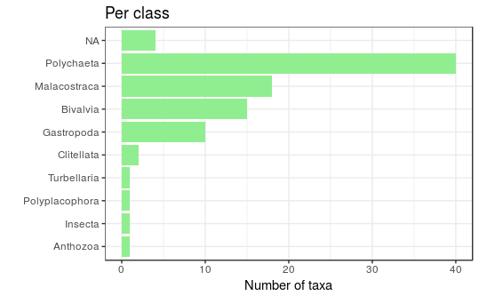

```r
## number of taxa per class
current.taxa.zostera %>%
  count(class, sort = TRUE) %>%
  ggplot(mapping = aes(x = reorder(class, n), y = n)) +
    geom_bar(stat = "identity", fill = "light green") +
    coord_flip() +
    labs(title = "Per class", x = "", y = "Number of taxa") +
    theme_bw()
```

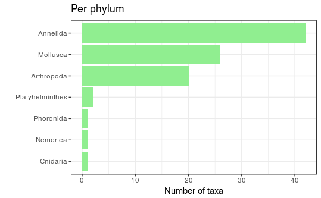

```r
## number of taxa per phylum
current.taxa.zostera %>%
  count(phylum, sort = TRUE) %>%
  ggplot(mapping = aes(x = reorder(phylum, n), y = n)) +
    geom_bar(stat = "identity", fill = "light green") +
    coord_flip() +
    labs(title = "Per phylum", x = "", y = "Number of taxa") +
    theme_bw()
```

Add in the more commonly used larger taxonomic groups (Polychaeta, Mollusca, Crustacea, and Varia).

```r
# the conditions have to be based on fields that do not contain NAs - or, more precisely, they have to be formulated in a way that DOESN'T return NA as a result of the evaluation. Otherwise the reclassification will result in those groups remaining as NA. This behaviour is caused by the way dplyr and mutate treat NAs; works as I expected in base R, so I didn't notice it before.
current.taxa.zostera <- current.taxa.zostera %>%
  mutate(group = case_when(
    phylum == "Mollusca" ~ "Mollusca",
    phylum == "Annelida" & class == "Polychaeta" ~ "Polychaeta",
    phylum == "Arthropoda" & subclass %in% c("Eumalacostraca", "Thecostraca") ~ "Crustacea",
    TRUE ~ "Varia"
  ))
current.taxa.zostera %>%
  count(group)
```

| group | n |
| --- | --- |
| Crustacea | 19 |
| Mollusca | 26 |
| Polychaeta | 40 |
| Varia | 8 |

Now plot the number of taxa per (common) taxonomic group, and save as file.

```r
plot.nb.taxa.by.group <- current.taxa.zostera %>%
  count(group) %>%
  ggplot(mapping = aes(x = reorder(group, n), y = n)) +
    geom_bar(stat = "identity", fill = "light green") +
    coord_flip() +
    labs(x = "", y = "Number of taxa") +
    theme(axis.text.x = element_text(size = rel(1.3)),
          axis.text.y = element_text(size = rel(1.3))) +
    theme_bw()
ggsave(file.path(figures.dir, "nb_taxa_by_tax_group_zostera.png"),
       plot.nb.taxa.by.group,
       dpi = 300)
```

**Crustacea** are represented by 18 families.  
**Polychaeta** are represented by 17 families.  
**Mollusca** are represented by 19 families.

The families with the highest number of species are:

```r
lapply(unique(current.taxa.zostera$group),
       function(x) {
         current.taxa.zostera %>%
           group_by(group) %>%
           count(family) %>%
           filter(group == x) %>%
           arrange(desc(n))
       })
```

| group | family | n |
| --- | --- | --- |
| Mollusca | Hydrobiidae | 2 |
| Mollusca | Lucinidae | 2 |
| Mollusca | Mytilidae | 2 |
| Mollusca | Nassariidae | 2 |
| Mollusca | Rissoidae | 2 |
| Mollusca | Semelidae | 2 |
| Mollusca | Veneridae | 2 |
| Mollusca | Arcidae | 1 |
| Mollusca | Cardiidae | 1 |
| Mollusca | Cerithiidae | 1 |

[output cut: 9 more lines]

| group | family | n |
| --- | --- | --- |
| Varia | NA | 7 |
| Varia | Chironomidae | 1 |

| group | family | n |
| --- | --- | --- |
| Polychaeta | Nereididae | 5 |
| Polychaeta | Syllidae | 5 |
| Polychaeta | Capitellidae | 3 |
| Polychaeta | Glyceridae | 3 |
| Polychaeta | Maldanidae | 3 |
| Polychaeta | Nephtyidae | 3 |
| Polychaeta | Phyllodocidae | 3 |
| Polychaeta | Spionidae | 3 |
| Polychaeta | Dorvilleidae | 2 |
| Polychaeta | Hesionidae | 2 |

[output cut: 7 more lines]

| group | family | n |
| --- | --- | --- |
| Crustacea | Nannastacidae | 2 |
| Crustacea | Ampeliscidae | 1 |
| Crustacea | Ampithoidae | 1 |
| Crustacea | Aoridae | 1 |
| Crustacea | Apseudidae | 1 |
| Crustacea | Atylidae | 1 |
| Crustacea | Balanidae | 1 |
| Crustacea | Bodotriidae | 1 |
| Crustacea | Calliopiidae | 1 |
| Crustacea | Cirolanidae | 1 |

[output cut: 8 more lines]

```
NA
```

NB again, this is a count of the frequency of occurrence of each family; it would be a real count of the number of species if all taxa were identified to species level. As it is, there are some identified to genus or family level - so this count is only indicative. It really should be checked manually and corrected, if needed.  
Now let’s calculate the contribution of each taxonomic group to the **overall community composition by abundance**.

```r
zoo.abnd.zostera.long %>%
  # exclude these poor larvae again (not that they contribute much, it's < 0.1%, but only to get the same numbers as are already in the text)
  filter(!species == "Polychaeta larvae") %>%
  summarize_tax_group_contr(current.taxa.zostera,
                            key.col = "species",
                            value.col = sp_count,
                            group) %>%
  arrange(desc(proportion))
```

| group | total | proportion |
| --- | --- | --- |
| Mollusca | 4531 | 0.3632938 |
| Polychaeta | 4377 | 0.3509461 |
| Varia | 1796 | 0.1440026 |
| Crustacea | 1768 | 0.1417575 |

Now calculate and plot the **contribution of the taxonomic groups to the abundance by station and year** in the seagrass communities.

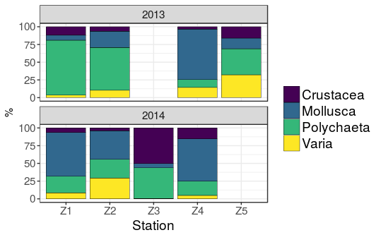

```r
tax.props.st.yr.zostera <- zoo.abnd.zostera.long %>%
  # exclude the larvae
  filter(!species == "Polychaeta larvae") %>%
  summarize_tax_group_contr(current.taxa.zostera,
                            key.col = "species",
                            value.col = sp_count,
                            station, year, group) %>%
  arrange(station, year)
(plot.tax.props.st.yr.zostera <- plot_tax_props(tax.props.st.yr.zostera, x.labels = "Z") +
    facet_wrap(~year, nrow = 2) +
    text_size(text.x = rel(1.3), text.y = rel(1.3), title.x = rel(1.3), legend.text = rel(1.3), strip.x = rel(1.3))
)
## save as file
ggsave(file.path(figures.dir, "tax_gr_props_st_yr_zostera.png"),
       plot.tax.props.st.yr.zostera,
       dpi = 300)
```

Check and plot the species which contribute the most to the abundance at each station.

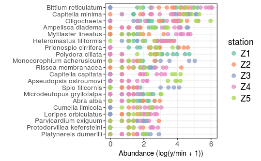

```r
top20.counts.zostera.st <- get_top_sp(zoo.abnd.zostera, nb.sp = 20)
plot.most.abnd.sp.zostera <- plot_top_n(top20.counts.zostera.st,
                                     aes(x = species, y = log_y_min(sp_count),
                                         colour = station),
                                     labs.legend = paste0("Z", as.numeric(unique(top20.counts.zostera.st$station))),
                                     lab.y = "Abundance (log(y/min + 1))",
                                     palette = "Set2"
                                     )
(plot.most.abnd.sp.zostera <- plot.most.abnd.sp.zostera  +
    text_size(text.x = rel(1.3), text.y = rel(1.15), legend.text = rel(1.2), legend.title = rel(1.2)) +
    scale_x_discrete(name = "", limits = rev(levels(top20.counts.zostera.st$species)))
)
## save as file
ggsave(file.path(figures.dir, "most_abnd_sp_st_zostera.png"),
       plot.most.abnd.sp.zostera,
       dpi = 300)
```

Now let’s calculate the same way the **overall community composition by biomass**.

```r
zoo.biomass.zostera.long %>%
  # exclude the larvae
  filter(!species == "Polychaeta larvae") %>%
  summarize_tax_group_contr(current.taxa.zostera,
                            key.col = "species",
                            value.col = sp_biomass,
                            group) %>%
  arrange(desc(proportion))
```

| group | total | proportion |
| --- | --- | --- |
| Mollusca | 64.8853 | 0.847778226 |
| Crustacea | 6.3788 | 0.083344113 |
| Polychaeta | 4.6868 | 0.061236782 |
| Varia | 0.5848 | 0.007640879 |

Then calculate and plot the **contribution of the taxonomic groups to the biomass by station and year**.

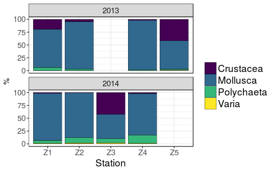

```r
tax.props.biomass.st.yr.zostera <- zoo.biomass.zostera.long %>%
  # exclude the larvae
  filter(!species == "Polychaeta larvae") %>%
  summarize_tax_group_contr(current.taxa.zostera,
                            key.col = "species",
                            value.col = sp_biomass,
                            station, year, group) %>%
  arrange(station, year)
# plot this
(plot.tax.props.biomass.st.yr.zostera <- plot_tax_props(tax.props.biomass.st.yr.zostera, x.labels = "Z") +
    facet_wrap(~year, nrow = 2) +
    text_size(text.x = rel(1.3), text.y = rel(1.3), title.x = rel(1.3), legend.text = rel(1.3), strip.x = rel(1.3))
)
## save as file
ggsave(file.path(figures.dir, "tax_gr_props_biomass_st_yr_zostera.png"),
       plot.tax.props.biomass.st.yr.zostera,
       dpi = 300)
```

Combine the proportions of the abundance and the biomass in one single plot.

```
Saving 15 x 7.01 cm image
```

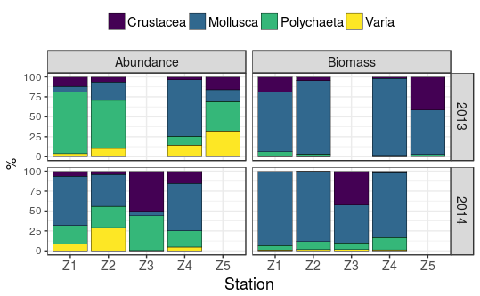

```r
## combine the proportional abundance and biomass tibbles into a single common (long) one
tax.props.zostera.all <- full_join(tax.props.st.yr.zostera,
                                tax.props.biomass.st.yr.zostera,
                                by = c("station", "year", "group")) %>%
  select(-starts_with("total")) %>%
  gather(key = variable, value = proportion, -station, -year, -group) %>%
  mutate(variable = case_when(variable == "proportion.x" ~ "Abundance",
                              variable == "proportion.y" ~ "Biomass"))
(plot.composite.tax.gr.props.zostera <- plot_tax_props(tax.props.zostera.all, x.labels = "Z") +
    facet_grid(year ~ variable) +
    theme(legend.position = "top", legend.key.size = unit(0.5, "cm")) +
    text_size(text.x = rel(1.2), text.y = rel(1), title.x = rel(1.2), legend.text = rel(1), strip.x = rel(1.2), strip.y = rel(1.2))
)
ggsave(file.path(figures.dir, "tax_gr_props_zostera_composite.png"),
       plot.composite.tax.gr.props.zostera,
       dpi = 300, width = 15, units = "cm")
```

Check and plot the species which contribute the most to the biomass at each station.

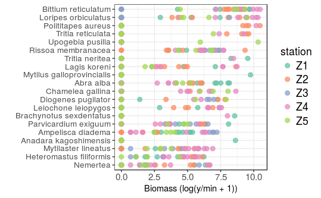

```r
## calculate the total biomass counts by species, then select the 20 with the highest biomass
top20.biomass.zostera.st <- get_top_sp(zoo.biomass.zostera, nb.sp = 20)
## plot them
plot.highest.biomass.sp.zostera <- plot_top_n(top20.biomass.zostera.st,
                                     aes(x = species, y = log_y_min(sp_count),
                                         colour = station),
                                     labs.legend = paste0("Z", as.numeric(unique(top20.biomass.zostera.st$station))),
                                     lab.y = "Biomass (log(y/min + 1))",
                                     palette = "Set2"
                                     )
(plot.highest.biomass.sp.zostera <- plot.highest.biomass.sp.zostera  +
    text_size(text.x = rel(1.3), text.y = rel(1.15), legend.text = rel(1.2), legend.title = rel(1.2)) +
    scale_x_discrete(name = "", limits = rev(levels(top20.biomass.zostera.st$species)))
)

## save as file
ggsave(file.path(figures.dir, "highest_biomass_sp_st_zostera.png"),
       plot.highest.biomass.sp.zostera,
       dpi = 300)
```

#### Macrozoobenthic communities in the seagrass and sand bottoms of Sozopol Bay (2012)

And we’ll repeat the analyses for the seagrass/sand communities in Sozopol Bay in 2012 (preliminary experiment).  
For this experiment, 3 seagrass sites in Sozpol Bay were chosen (Konski, Ribka, Gradina), with 2 stations within each (total = 6 stations).  
At each station, 4 samples were taken within the seagrass bed, and another 4 - outside it, in the bare sand bottom.  
The purpose was to compare the macrobenthic community composition & structure at the level of the sites, as well as between sites, in the 2 types of habitat (sand and seagrass).  
Nevertheless, the same analyses as before will be applied first as if every station were independent (even if it complicates the work somewhat).

Import the zoobenthic abundance & biomass data.

```r
## import & check the abundance data. Dimensions should be 48 x 205 (5 metadata + 200 species columns); all species columns should be numeric.
(zoo.abnd.2012 <- import_zoo_data(data.dir = data.dir,
                                     zoo.data = "zoo_abnd_2012_orig.csv",
                                     meta.labels = c("station", "month", "year", "habitat", "replicate")))
```

|  | station | month | year | habitat | replicate | Abra alba | Abra prismatica | Abra segmentum | Abra sp. | Acanthocardia tuberculata | Acari | Actiniaria | Alitta succinea | Ampelisca diadema | Ampharetidae | Amphibalanus improvisus | Amphipoda | Amphitritides gracilis | Ampithoe sp. | Anadara kagoshimensis | Aonides paucibranchiata | Apherusa bispinosa | Apseudopsis ostroumovi | Aricidea claudiae | Bathyporeia guilliamsoniana | Bittium reticulatum | Bivalvia undet. | Bodotria arenosa | Brachynotus sexdentatus | … |
| --- | --- | --- | --- | --- | --- | --- | --- | --- | --- | --- | --- | --- | --- | --- | --- | --- | --- | --- | --- | --- | --- | --- | --- | --- | --- | --- | --- | --- | --- | --- |
| 1 | Gradina1 | 7 | 2012 | S | a | 0 | 0 | 0 | 0 | 0 | 0 | 0 | 0 | 0 | 0 | 0 | 0 | 0 | 0 | 0 | 0 | 0 | 0 | 0 | 0 | 4 | 0 | 0 | 0 | … |
| 2 | Gradina1 | 7 | 2012 | S | b | 0 | 0 | 0 | 0 | 0 | 0 | 0 | 0 | 0 | 0 | 0 | 0 | 0 | 0 | 0 | 0 | 0 | 0 | 0 | 0 | 0 | 0 | 0 | 0 | … |
| 3 | Gradina1 | 7 | 2012 | S | c | 0 | 0 | 0 | 0 | 0 | 0 | 0 | 0 | 0 | 0 | 0 | 0 | 0 | 0 | 0 | 0 | 0 | 0 | 0 | 0 | 0 | 0 | 0 | 0 | … |
| 4 | Gradina1 | 7 | 2012 | S | d | 0 | 0 | 0 | 0 | 0 | 0 | 0 | 0 | 0 | 0 | 0 | 0 | 0 | 0 | 0 | 0 | 0 | 0 | 0 | 0 | 0 | 0 | 0 | 0 | … |
| 5 | Gradina1 | 7 | 2012 | Z | a | 0 | 0 | 0 | 0 | 0 | 0 | 0 | 0 | 0 | 0 | 0 | 0 | 0 | 0 | 0 | 0 | 0 | 0 | 0 | 0 | 55 | 0 | 0 | 0 | … |
| 6 | Gradina1 | 7 | 2012 | Z | b | 0 | 0 | 0 | 0 | 0 | 0 | 0 | 0 | 0 | 0 | 0 | 0 | 0 | 0 | 0 | 0 | 0 | 0 | 0 | 0 | 66 | 0 | 0 | 0 | … |
| 7 | Gradina1 | 7 | 2012 | Z | c | 0 | 1 | 0 | 0 | 0 | 0 | 0 | 0 | 0 | 0 | 0 | 0 | 0 | 0 | 0 | 0 | 0 | 0 | 0 | 0 | 54 | 0 | 0 | 0 | … |
| 8 | Gradina1 | 7 | 2012 | Z | d | 0 | 0 | 0 | 0 | 0 | 0 | 0 | 0 | 0 | 0 | 0 | 0 | 0 | 0 | 0 | 0 | 0 | 0 | 0 | 0 | 39 | 0 | 0 | 0 | … |
| 9 | Gradina2 | 7 | 2012 | S | a | 0 | 0 | 1 | 0 | 0 | 0 | 0 | 0 | 0 | 0 | 0 | 0 | 0 | 0 | 0 | 0 | 0 | 0 | 0 | 0 | 1 | 0 | 0 | 0 | … |
| 10 | Gradina2 | 7 | 2012 | S | b | 0 | 1 | 0 | 0 | 0 | 0 | 0 | 0 | 0 | 0 | 0 | 0 | 0 | 0 | 0 | 0 | 0 | 0 | 0 | 0 | 3 | 0 | 0 | 0 | … |

[output cut: 38 more lines]

Convert the month and year back to numeric, then arrange the data frame - by station (first converting to factor), then year and month, then habitat. In this experiment, there were 2 habitats - sand and seagrass.

```r
(zoo.abnd.2012 <- zoo.abnd.2012 %>%
   mutate(year = as.numeric(year),
          month = as.numeric(month),
          station = factor(station, levels = c("Konski1", "Konski2", "Ribka1", "Ribka2", "Gradina1", "Gradina2"))) %>%
   arrange(station, year, month, habitat))
```

| station | month | year | habitat | replicate | Abra alba | Abra prismatica | Abra segmentum | Abra sp. | Acanthocardia tuberculata | Acari | Actiniaria | Alitta succinea | Ampelisca diadema | Ampharetidae | Amphibalanus improvisus | Amphipoda | Amphitritides gracilis | Ampithoe sp. | Anadara kagoshimensis | Aonides paucibranchiata | Apherusa bispinosa | Apseudopsis ostroumovi | Aricidea claudiae | Bathyporeia guilliamsoniana | Bittium reticulatum | Bivalvia undet. | Bodotria arenosa | Brachynotus sexdentatus | Brachystomia scalaris | … |
| --- | --- | --- | --- | --- | --- | --- | --- | --- | --- | --- | --- | --- | --- | --- | --- | --- | --- | --- | --- | --- | --- | --- | --- | --- | --- | --- | --- | --- | --- | --- |
| Konski1 | 7 | 2012 | S | a | 0 | 0 | 4 | 0 | 0 | 0 | 0 | 0 | 5 | 0 | 0 | 0 | 0 | 0 | 0 | 0 | 0 | 0 | 0 | 0 | 16 | 0 | 0 | 0 | 0 | … |
| Konski1 | 7 | 2012 | S | b | 0 | 0 | 0 | 0 | 0 | 0 | 0 | 0 | 1 | 0 | 0 | 2 | 0 | 0 | 0 | 0 | 0 | 0 | 0 | 0 | 20 | 0 | 0 | 0 | 0 | … |
| Konski1 | 7 | 2012 | S | c | 0 | 0 | 4 | 0 | 0 | 0 | 0 | 0 | 0 | 0 | 0 | 0 | 0 | 0 | 0 | 0 | 0 | 0 | 0 | 0 | 8 | 0 | 0 | 0 | 0 | … |
| Konski1 | 7 | 2012 | S | d | 0 | 0 | 0 | 0 | 0 | 0 | 0 | 0 | 2 | 0 | 0 | 1 | 0 | 0 | 0 | 0 | 0 | 0 | 0 | 0 | 32 | 0 | 0 | 0 | 0 | … |
| Konski1 | 7 | 2012 | Z | a | 0 | 0 | 0 | 0 | 0 | 0 | 0 | 0 | 0 | 0 | 1 | 0 | 0 | 0 | 0 | 0 | 0 | 0 | 0 | 0 | 138 | 0 | 0 | 0 | 0 | … |
| Konski1 | 7 | 2012 | Z | b | 0 | 0 | 2 | 0 | 0 | 0 | 0 | 0 | 0 | 0 | 0 | 0 | 0 | 0 | 0 | 0 | 0 | 0 | 0 | 0 | 200 | 0 | 0 | 0 | 0 | … |
| Konski1 | 7 | 2012 | Z | c | 0 | 2 | 0 | 0 | 0 | 0 | 0 | 0 | 3 | 0 | 2 | 1 | 0 | 0 | 0 | 0 | 0 | 0 | 0 | 0 | 234 | 0 | 0 | 0 | 0 | … |
| Konski1 | 7 | 2012 | Z | d | 0 | 0 | 0 | 0 | 0 | 0 | 0 | 0 | 2 | 0 | 6 | 1 | 0 | 0 | 0 | 0 | 0 | 0 | 0 | 0 | 205 | 0 | 0 | 0 | 0 | … |
| Konski2 | 7 | 2012 | S | a | 0 | 0 | 0 | 0 | 0 | 0 | 0 | 0 | 0 | 1 | 0 | 0 | 0 | 0 | 0 | 0 | 0 | 0 | 0 | 0 | 80 | 0 | 0 | 0 | 0 | … |
| Konski2 | 7 | 2012 | S | b | 0 | 0 | 0 | 0 | 0 | 0 | 0 | 0 | 0 | 0 | 0 | 0 | 0 | 0 | 0 | 0 | 0 | 0 | 0 | 0 | 12 | 0 | 0 | 0 | 0 | … |

[output cut: 38 more lines]

Now on to the biomass!

```r
## import & check out the biomass data.
(zoo.biomass.2012 <- import_zoo_data(data.dir = data.dir,
                                        zoo.data = "zoo_biomass_2012_orig.csv",
                                        meta.labels = c("station", "month", "year", "habitat", "replicate")))
```

|  | station | month | year | habitat | replicate | Abra alba | Abra prismatica | Abra segmentum | Abra sp. | Acanthocardia tuberculata | Acari | Actiniaria | Alitta succinea | Ampelisca diadema | Ampharetidae | Amphibalanus improvisus | Amphipoda | Amphitritides gracilis | Ampithoe sp. | Anadara kagoshimensis | Aonides paucibranchiata | Apherusa bispinosa | Apseudopsis ostroumovi | Aricidea claudiae | Bathyporeia guilliamsoniana | Bittium reticulatum | Bivalvia undet. | Bodotria arenosa | Brachynotus sexdentatus | … |
| --- | --- | --- | --- | --- | --- | --- | --- | --- | --- | --- | --- | --- | --- | --- | --- | --- | --- | --- | --- | --- | --- | --- | --- | --- | --- | --- | --- | --- | --- | --- |
| 1 | Gradina1 | 7 | 2012 | S | a | 0 | 0.0000 | 0.0000 | 0 | 0 | 0 | 0 | 0 | 0.0000 | 0.0000 | 0.0000 | 0.0000 | 0 | 0 | 0 | 0 | 0 | 0 | 0 | 0 | 0.0216 | 0 | 0 | 0.00 | … |
| 2 | Gradina1 | 7 | 2012 | S | b | 0 | 0.0000 | 0.0000 | 0 | 0 | 0 | 0 | 0 | 0.0000 | 0.0000 | 0.0000 | 0.0000 | 0 | 0 | 0 | 0 | 0 | 0 | 0 | 0 | 0.0000 | 0 | 0 | 0.00 | … |
| 3 | Gradina1 | 7 | 2012 | S | c | 0 | 0.0000 | 0.0000 | 0 | 0 | 0 | 0 | 0 | 0.0000 | 0.0000 | 0.0000 | 0.0000 | 0 | 0 | 0 | 0 | 0 | 0 | 0 | 0 | 0.0000 | 0 | 0 | 0.00 | … |
| 4 | Gradina1 | 7 | 2012 | S | d | 0 | 0.0000 | 0.0000 | 0 | 0 | 0 | 0 | 0 | 0.0000 | 0.0000 | 0.0000 | 0.0000 | 0 | 0 | 0 | 0 | 0 | 0 | 0 | 0 | 0.0000 | 0 | 0 | 0.00 | … |
| 5 | Gradina1 | 7 | 2012 | Z | a | 0 | 0.0000 | 0.0000 | 0 | 0 | 0 | 0 | 0 | 0.0000 | 0.0000 | 0.0000 | 0.0000 | 0 | 0 | 0 | 0 | 0 | 0 | 0 | 0 | 0.2400 | 0 | 0 | 0.00 | … |
| 6 | Gradina1 | 7 | 2012 | Z | b | 0 | 0.0000 | 0.0000 | 0 | 0 | 0 | 0 | 0 | 0.0000 | 0.0000 | 0.0000 | 0.0000 | 0 | 0 | 0 | 0 | 0 | 0 | 0 | 0 | 0.6200 | 0 | 0 | 0.00 | … |
| 7 | Gradina1 | 7 | 2012 | Z | c | 0 | 0.0004 | 0.0000 | 0 | 0 | 0 | 0 | 0 | 0.0000 | 0.0000 | 0.0000 | 0.0000 | 0 | 0 | 0 | 0 | 0 | 0 | 0 | 0 | 0.4100 | 0 | 0 | 0.00 | … |
| 8 | Gradina1 | 7 | 2012 | Z | d | 0 | 0.0000 | 0.0000 | 0 | 0 | 0 | 0 | 0 | 0.0000 | 0.0000 | 0.0000 | 0.0000 | 0 | 0 | 0 | 0 | 0 | 0 | 0 | 0 | 0.2300 | 0 | 0 | 0.00 | … |
| 9 | Gradina2 | 7 | 2012 | S | a | 0 | 0.0000 | 0.0252 | 0 | 0 | 0 | 0 | 0 | 0.0000 | 0.0000 | 0.0000 | 0.0000 | 0 | 0 | 0 | 0 | 0 | 0 | 0 | 0 | 0.0050 | 0 | 0 | 0.00 | … |
| 10 | Gradina2 | 7 | 2012 | S | b | 0 | 0.0032 | 0.0000 | 0 | 0 | 0 | 0 | 0 | 0.0000 | 0.0000 | 0.0000 | 0.0000 | 0 | 0 | 0 | 0 | 0 | 0 | 0 | 0 | 0.0136 | 0 | 0 | 0.00 | … |

[output cut: 38 more lines]

```r
# same expected structure as the abundance
```

```r
(zoo.biomass.2012 <- zoo.biomass.2012 %>%
   mutate(year = as.numeric(year),
          month = as.numeric(month),
          station = factor(station, levels = c("Konski1", "Konski2", "Ribka1", "Ribka2", "Gradina1", "Gradina2"))) %>%
   arrange(station, year, month))
```

| station | month | year | habitat | replicate | Abra alba | Abra prismatica | Abra segmentum | Abra sp. | Acanthocardia tuberculata | Acari | Actiniaria | Alitta succinea | Ampelisca diadema | Ampharetidae | Amphibalanus improvisus | Amphipoda | Amphitritides gracilis | Ampithoe sp. | Anadara kagoshimensis | Aonides paucibranchiata | Apherusa bispinosa | Apseudopsis ostroumovi | Aricidea claudiae | Bathyporeia guilliamsoniana | Bittium reticulatum | Bivalvia undet. | Bodotria arenosa | Brachynotus sexdentatus | Brachystomia scalaris | … |
| --- | --- | --- | --- | --- | --- | --- | --- | --- | --- | --- | --- | --- | --- | --- | --- | --- | --- | --- | --- | --- | --- | --- | --- | --- | --- | --- | --- | --- | --- | --- |
| Konski1 | 7 | 2012 | S | a | 0 | 0.0000 | 0.5608 | 0 | 0 | 0 | 0 | 0 | 0.0052 | 0.0000 | 0.0000 | 0.0000 | 0 | 0 | 0 | 0 | 0 | 0 | 0 | 0 | 0.1036 | 0 | 0 | 0.00 | 0 | … |
| Konski1 | 7 | 2012 | S | b | 0 | 0.0000 | 0.0000 | 0 | 0 | 0 | 0 | 0 | 0.0030 | 0.0000 | 0.0000 | 0.0015 | 0 | 0 | 0 | 0 | 0 | 0 | 0 | 0 | 0.1104 | 0 | 0 | 0.00 | 0 | … |
| Konski1 | 7 | 2012 | S | c | 0 | 0.0000 | 0.0452 | 0 | 0 | 0 | 0 | 0 | 0.0000 | 0.0000 | 0.0000 | 0.0000 | 0 | 0 | 0 | 0 | 0 | 0 | 0 | 0 | 0.0696 | 0 | 0 | 0.00 | 0 | … |
| Konski1 | 7 | 2012 | S | d | 0 | 0.0000 | 0.0000 | 0 | 0 | 0 | 0 | 0 | 0.0001 | 0.0000 | 0.0000 | 0.0025 | 0 | 0 | 0 | 0 | 0 | 0 | 0 | 0 | 0.1260 | 0 | 0 | 0.00 | 0 | … |
| Konski1 | 7 | 2012 | Z | a | 0 | 0.0000 | 0.0000 | 0 | 0 | 0 | 0 | 0 | 0.0000 | 0.0000 | 0.0045 | 0.0000 | 0 | 0 | 0 | 0 | 0 | 0 | 0 | 0 | 1.2731 | 0 | 0 | 0.00 | 0 | … |
| Konski1 | 7 | 2012 | Z | b | 0 | 0.0000 | 0.0140 | 0 | 0 | 0 | 0 | 0 | 0.0000 | 0.0000 | 0.0000 | 0.0000 | 0 | 0 | 0 | 0 | 0 | 0 | 0 | 0 | 1.5003 | 0 | 0 | 0.00 | 0 | … |
| Konski1 | 7 | 2012 | Z | c | 0 | 0.0110 | 0.0000 | 0 | 0 | 0 | 0 | 0 | 0.0025 | 0.0000 | 0.0026 | 0.0001 | 0 | 0 | 0 | 0 | 0 | 0 | 0 | 0 | 1.4974 | 0 | 0 | 0.00 | 0 | … |
| Konski1 | 7 | 2012 | Z | d | 0 | 0.0000 | 0.0000 | 0 | 0 | 0 | 0 | 0 | 0.0015 | 0.0000 | 0.0293 | 0.0001 | 0 | 0 | 0 | 0 | 0 | 0 | 0 | 0 | 2.0755 | 0 | 0 | 0.00 | 0 | … |
| Konski2 | 7 | 2012 | S | a | 0 | 0.0000 | 0.0000 | 0 | 0 | 0 | 0 | 0 | 0.0000 | 0.0010 | 0.0000 | 0.0000 | 0 | 0 | 0 | 0 | 0 | 0 | 0 | 0 | 0.7444 | 0 | 0 | 0.00 | 0 | … |
| Konski2 | 7 | 2012 | S | b | 0 | 0.0000 | 0.0000 | 0 | 0 | 0 | 0 | 0 | 0.0000 | 0.0000 | 0.0000 | 0.0000 | 0 | 0 | 0 | 0 | 0 | 0 | 0 | 0 | 0.1652 | 0 | 0 | 0.00 | 0 | … |

[output cut: 38 more lines]

Great! To be on the safe side, save the cleaned abundance & biomass data frames.

```r
write_csv(zoo.abnd.2012,
          path = file.path(save.dir, "abnd_2012_orig_clean.csv"))
write_csv(zoo.biomass.2012,
          path = file.path(save.dir, "biomass_2012_orig_clean.csv"))
```

Remove the species that are absent from the current dataset, as before.

```r
(zoo.abnd.2012 <- zoo.abnd.2012 %>%
  gather(key = species, value = sp_count, -c(station:replicate)) %>%
  group_by(species) %>%
  filter(sp_count > 0) %>%
  spread(species, sp_count, fill = 0) %>%
  arrange(station, year))
```

| station | month | year | habitat | replicate | Abra prismatica | Abra segmentum | Ampelisca diadema | Ampharetidae | Amphibalanus improvisus | Amphipoda | Bittium reticulatum | Brachynotus sexdentatus | Capitella capitata | Capitellidae | Chamelea gallina | Corophiidae | Cumacea | Cytharella costulata | Diogenes pugilator | Eunice vittata | Eunicidae | Eurydice pontica | Glycera sp. | Harmothoe imbricata | Heteromastus filiformis | Hydrobia acuta | Lagis koreni | Leiochone leiopygos | Lepidochitona cinerea | … |
| --- | --- | --- | --- | --- | --- | --- | --- | --- | --- | --- | --- | --- | --- | --- | --- | --- | --- | --- | --- | --- | --- | --- | --- | --- | --- | --- | --- | --- | --- | --- |
| Konski1 | 7 | 2012 | S | a | 0 | 4 | 5 | 0 | 0 | 0 | 16 | 0 | 0 | 0 | 12 | 0 | 0 | 0 | 2 | 0 | 0 | 0 | 0 | 0 | 22 | 0 | 0 | 0 | 0 | … |
| Konski1 | 7 | 2012 | S | b | 0 | 0 | 1 | 0 | 0 | 2 | 20 | 0 | 7 | 0 | 8 | 0 | 1 | 0 | 0 | 0 | 0 | 1 | 0 | 0 | 9 | 0 | 1 | 0 | 0 | … |
| Konski1 | 7 | 2012 | S | c | 0 | 4 | 0 | 0 | 0 | 0 | 8 | 0 | 3 | 0 | 16 | 1 | 1 | 0 | 1 | 0 | 0 | 0 | 0 | 0 | 5 | 0 | 0 | 0 | 0 | … |
| Konski1 | 7 | 2012 | S | d | 0 | 0 | 2 | 0 | 0 | 1 | 32 | 0 | 1 | 0 | 0 | 0 | 0 | 0 | 0 | 0 | 0 | 0 | 0 | 0 | 3 | 4 | 0 | 0 | 0 | … |
| Konski1 | 7 | 2012 | Z | a | 0 | 0 | 0 | 0 | 1 | 0 | 138 | 0 | 0 | 0 | 0 | 0 | 0 | 0 | 0 | 0 | 0 | 0 | 0 | 0 | 1 | 0 | 0 | 0 | 0 | … |
| Konski1 | 7 | 2012 | Z | b | 0 | 2 | 0 | 0 | 0 | 0 | 200 | 0 | 0 | 0 | 1 | 0 | 0 | 1 | 0 | 0 | 0 | 0 | 0 | 0 | 0 | 0 | 0 | 0 | 0 | … |
| Konski1 | 7 | 2012 | Z | c | 2 | 0 | 3 | 0 | 2 | 1 | 234 | 0 | 3 | 0 | 0 | 0 | 7 | 0 | 0 | 0 | 1 | 0 | 0 | 0 | 7 | 0 | 1 | 0 | 0 | … |
| Konski1 | 7 | 2012 | Z | d | 0 | 0 | 2 | 0 | 6 | 1 | 205 | 0 | 4 | 0 | 2 | 0 | 1 | 1 | 0 | 0 | 0 | 0 | 0 | 0 | 4 | 0 | 0 | 0 | 0 | … |
| Konski2 | 7 | 2012 | S | a | 0 | 0 | 0 | 1 | 0 | 0 | 80 | 0 | 11 | 0 | 4 | 2 | 0 | 0 | 1 | 0 | 0 | 0 | 0 | 0 | 7 | 0 | 0 | 0 | 0 | … |
| Konski2 | 7 | 2012 | S | b | 0 | 0 | 0 | 0 | 0 | 0 | 12 | 0 | 2 | 0 | 0 | 0 | 0 | 0 | 0 | 0 | 0 | 0 | 0 | 0 | 0 | 0 | 0 | 0 | 0 | … |

[output cut: 38 more lines]

```r
(zoo.biomass.2012 <- zoo.biomass.2012 %>%
  gather(key = species, value = sp_biomass, -c(station:replicate)) %>%
  group_by(species) %>%
  filter(sp_biomass > 0) %>%
  spread(species, sp_biomass, fill = 0) %>%
  arrange(station, year))
```

| station | month | year | habitat | replicate | Abra prismatica | Abra segmentum | Ampelisca diadema | Ampharetidae | Amphibalanus improvisus | Amphipoda | Bittium reticulatum | Brachynotus sexdentatus | Capitella capitata | Capitellidae | Chamelea gallina | Corophiidae | Cumacea | Cytharella costulata | Diogenes pugilator | Eunice vittata | Eunicidae | Eurydice pontica | Glycera sp. | Harmothoe imbricata | Heteromastus filiformis | Hydrobia acuta | Lagis koreni | Leiochone leiopygos | Lepidochitona cinerea | … |
| --- | --- | --- | --- | --- | --- | --- | --- | --- | --- | --- | --- | --- | --- | --- | --- | --- | --- | --- | --- | --- | --- | --- | --- | --- | --- | --- | --- | --- | --- | --- |
| Konski1 | 7 | 2012 | S | a | 0.0000 | 0.5608 | 0.0052 | 0.0000 | 0.0000 | 0.0000 | 0.1036 | 0.00 | 0.0000 | 0e+00 | 3.6664 | 0e+00 | 0.0000 | 0.0000 | 0.0626 | 0.000 | 0e+00 | 0e+00 | 0.0000 | 0e+00 | 0.0055 | 0.000 | 0.0000 | 0e+00 | 0.0000 | … |
| Konski1 | 7 | 2012 | S | b | 0.0000 | 0.0000 | 0.0030 | 0.0000 | 0.0000 | 0.0015 | 0.1104 | 0.00 | 0.0006 | 0e+00 | 0.2656 | 0e+00 | 0.0001 | 0.0000 | 0.0000 | 0.000 | 0e+00 | 2e-04 | 0.0000 | 0e+00 | 0.0025 | 0.000 | 0.0010 | 0e+00 | 0.0000 | … |
| Konski1 | 7 | 2012 | S | c | 0.0000 | 0.0452 | 0.0000 | 0.0000 | 0.0000 | 0.0000 | 0.0696 | 0.00 | 0.0020 | 0e+00 | 0.3264 | 1e-04 | 0.0001 | 0.0000 | 0.0102 | 0.000 | 0e+00 | 0e+00 | 0.0000 | 0e+00 | 0.0105 | 0.000 | 0.0000 | 0e+00 | 0.0000 | … |
| Konski1 | 7 | 2012 | S | d | 0.0000 | 0.0000 | 0.0001 | 0.0000 | 0.0000 | 0.0025 | 0.1260 | 0.00 | 0.0003 | 0e+00 | 0.0000 | 0e+00 | 0.0000 | 0.0000 | 0.0000 | 0.000 | 0e+00 | 0e+00 | 0.0000 | 0e+00 | 0.0001 | 0.008 | 0.0000 | 0e+00 | 0.0000 | … |
| Konski1 | 7 | 2012 | Z | a | 0.0000 | 0.0000 | 0.0000 | 0.0000 | 0.0045 | 0.0000 | 1.2731 | 0.00 | 0.0000 | 0e+00 | 0.0000 | 0e+00 | 0.0000 | 0.0000 | 0.0000 | 0.000 | 0e+00 | 0e+00 | 0.0000 | 0e+00 | 0.0001 | 0.000 | 0.0000 | 0e+00 | 0.0000 | … |
| Konski1 | 7 | 2012 | Z | b | 0.0000 | 0.0140 | 0.0000 | 0.0000 | 0.0000 | 0.0000 | 1.5003 | 0.00 | 0.0000 | 0e+00 | 0.0014 | 0e+00 | 0.0000 | 0.0034 | 0.0000 | 0.000 | 0e+00 | 0e+00 | 0.0000 | 0e+00 | 0.0000 | 0.000 | 0.0000 | 0e+00 | 0.0000 | … |
| Konski1 | 7 | 2012 | Z | c | 0.0110 | 0.0000 | 0.0025 | 0.0000 | 0.0026 | 0.0001 | 1.4974 | 0.00 | 0.0025 | 0e+00 | 0.0000 | 0e+00 | 0.0033 | 0.0000 | 0.0000 | 0.000 | 1e-04 | 0e+00 | 0.0000 | 0e+00 | 0.0059 | 0.000 | 0.0001 | 0e+00 | 0.0000 | … |
| Konski1 | 7 | 2012 | Z | d | 0.0000 | 0.0000 | 0.0015 | 0.0000 | 0.0293 | 0.0001 | 2.0755 | 0.00 | 0.0009 | 0e+00 | 0.0209 | 0e+00 | 0.0004 | 0.0057 | 0.0000 | 0.000 | 0e+00 | 0e+00 | 0.0000 | 0e+00 | 0.0035 | 0.000 | 0.0000 | 0e+00 | 0.0000 | … |
| Konski2 | 7 | 2012 | S | a | 0.0000 | 0.0000 | 0.0000 | 0.0010 | 0.0000 | 0.0000 | 0.7444 | 0.00 | 0.0047 | 0e+00 | 0.9228 | 1e-04 | 0.0000 | 0.0000 | 0.0445 | 0.000 | 0e+00 | 0e+00 | 0.0000 | 0e+00 | 0.0051 | 0.000 | 0.0000 | 0e+00 | 0.0000 | … |
| Konski2 | 7 | 2012 | S | b | 0.0000 | 0.0000 | 0.0000 | 0.0000 | 0.0000 | 0.0000 | 0.1652 | 0.00 | 0.0001 | 0e+00 | 0.0000 | 0e+00 | 0.0000 | 0.0000 | 0.0000 | 0.000 | 0e+00 | 0e+00 | 0.0000 | 0e+00 | 0.0000 | 0.000 | 0.0000 | 0e+00 | 0.0000 | … |

[output cut: 38 more lines]

Ready to proceed with the community structure & composition analyses!

```r
names(select(zoo.abnd.2012, -c(station:replicate)))
```

```
 [1] "Abra prismatica"
 [2] "Abra segmentum"
 [3] "Ampelisca diadema"
 [4] "Ampharetidae"
 [5] "Amphibalanus improvisus"
 [6] "Amphipoda"
 [7] "Bittium reticulatum"
 [8] "Brachynotus sexdentatus"
 [9] "Capitella capitata"
[10] "Capitellidae"
[11] "Chamelea gallina"
[12] "Corophiidae"
[13] "Cumacea"
[14] "Cytharella costulata"
[15] "Diogenes pugilator"
```

[output cut: 43 more lines]

Wow, a whole lot of them are only identified to family level.. Goes to show what I knew about macroinvertebrate taxonomy then, which is zilch. I most likely intended to go back at some point and identify them, but never got round to it, and then destroyed them while measuring the biomass.  
In any case, the 2012 dataset should be regarded as very preliminary, with a really low confidence level, and all conclusions based on it should only be tentative. It will not be included in the other seagrass analyses despite the similar sampling strategy and methods, because due to the low species richness it biases the whole process (e.g. it might be concluded that seagrasses in Sozopol Bay were in a worse ecological state in 2012, which then improved markedly in 2013-2014, but this is not the case - the real variables that improved in that time were my sorting skills and knowledge of taxonomy).

In the **seagrasses** in Sozopol Bay, there were 47 taxa overall in 2012.  
In the **sands** in Sozopol Bay, there were 42 taxa overall in 2012.

Let’s compare the taxa between seagrass and sand communities in Sozopol Bay.

```r
## all taxa found in seagrasses
taxa.zostera.2012 <- unique(zoo.abnd.2012 %>%
  filter(habitat == "Z") %>%
  gather(key = species, value = sp_count, -c(station:replicate)) %>%
  group_by(species) %>%
  filter(sp_count > 0) %>%
  select(species) %>%
  ungroup()
  )
## all taxa found in sand
taxa.sand.2012 <- unique(zoo.abnd.2012 %>%
  filter(habitat == "S") %>%
  gather(key = species, value = sp_count, -c(station:replicate)) %>%
  group_by(species) %>%
  filter(sp_count > 0) %>%
  select(species) %>%
  ungroup()
)
```

There are 31 taxa found in both sand and seagrass in 2012. Let’s see them:

```r
# we're looking them up in this order, because there are less taxa in sand than in seagrass in 2012
taxa.zostera.2012$species[which(taxa.sand.2012$species %in% taxa.zostera.2012$species)]
```

```
 [1] "Abra prismatica"
 [2] "Abra segmentum"
 [3] "Ampelisca diadema"
 [4] "Amphipoda"
 [5] "Bittium reticulatum"
 [6] "Brachynotus sexdentatus"
 [7] "Capitella capitata"
 [8] "Capitellidae"
 [9] "Chamelea gallina"
[10] "Corophiidae"
[11] "Cumacea"
[12] "Harmothoe imbricata"
[13] "Lagis koreni"
[14] "Leiochone leiopygos"
[15] "Lepidochitona cinerea"
```

[output cut: 16 more lines]

The taxa found **only in sand** are:

```r
setdiff(taxa.sand.2012, taxa.zostera.2012)$species
```

```
 [1] "Ampharetidae"         "Diogenes pugilator"
 [3] "Eurydice pontica"     "Glycera sp."
 [5] "Hydrobia acuta"       "Magelonidae"
 [7] "Nephtyidae"           "Parvicardium exiguum"
 [9] "Polydora ciliata"     "Protodrilus sp."
[11] "Spionidae"
```

The taxa found **only in seagrass** are:

```r
setdiff(taxa.zostera.2012, taxa.sand.2012)$species
```

```
 [1] "Brachynotus sexdentatus" "Capitellidae"
 [3] "Eunice vittata"          "Eunicidae"
 [5] "Harmothoe imbricata"     "Leiochone leiopygos"
 [7] "Lucinella divaricata"    "Microphthalmus fragilis"
 [9] "Paraonidae"              "Polititapes aureus"
[11] "Rissoa sp."              "Rissoa splendida"
[13] "Salvatoria clavata"      "Stenosoma capito"
[15] "Tricolia pullus"         "Tritia reticulata"
```

The **total number of taxa per station** in **seagrass** is:

```r
specnumber(filter(zoo.abnd.2012, habitat == "Z") %>% select(-c(station:replicate)), groups = filter(zoo.abnd.2012, habitat == "Z")$station)
```

```
 Konski1  Konski2   Ribka1   Ribka2 Gradina1 Gradina2
      24       28       15       17       12       26
```

The **total number of taxa per station** in **sand** is:

```r
specnumber(filter(zoo.abnd.2012, habitat == "S") %>% select(-c(station:replicate)), groups = filter(zoo.abnd.2012, habitat == "S")$station)
```

```
 Konski1  Konski2   Ribka1   Ribka2 Gradina1 Gradina2
      26       29        8        9        6       11
```

Again, we’re going to transform the two data frames (abundance and biomass) to long format, which is more convenient.

```r
zoo.abnd.2012.long <- zoo.abnd.2012 %>%
  gather(key = species, value = sp_count, -c(station:replicate))
zoo.biomass.2012.long <- zoo.biomass.2012 %>%
  gather(key = species, value = sp_biomass, -c(station:replicate))
```

The **summarized number of taxa** by station and year is:

```r
zoo.abnd.2012.long %>%
  group_by(habitat, station, replicate) %>%
  transmute(total_nb_taxa = specnumber(sp_count)) %>%
  distinct(station, habitat, total_nb_taxa) %>%
  group_by(station, habitat) %>%
  # rounded to the nearest integer, because there is no such thing as half a species
  summarise(mean_nb_taxa = round(mean(total_nb_taxa)),
            sd_nb_taxa = round(sd(total_nb_taxa)),
            nb_replicates = n()) %>%
  arrange(habitat, station)
```

| station | habitat | mean_nb_taxa | sd_nb_taxa | nb_replicates |
| --- | --- | --- | --- | --- |
| Konski1 | S | 14 | 2 | 4 |
| Konski2 | S | 14 | 7 | 4 |
| Ribka1 | S | 4 | 2 | 4 |
| Ribka2 | S | 4 | 3 | 4 |
| Gradina1 | S | 3 | 2 | 4 |
| Gradina2 | S | 5 | 2 | 4 |
| Konski1 | Z | 11 | 6 | 4 |
| Konski2 | Z | 16 | 5 | 4 |
| Ribka1 | Z | 8 | 3 | 4 |
| Ribka2 | Z | 8 | 3 | 4 |

[output cut: 2 more lines]

The **summarized abundance** by station and year is:

```r
summarize_zoo_data(zoo.abnd.2012.long, value.col = sp_count, per.m2 = 1/0.0078, round.to = 0)
```

| habitat | station | year | sp_count_mean | sp_count_sd | nb_replicates |
| --- | --- | --- | --- | --- | --- |
| S | Konski1 | 2012 | 12500 | 2004 | 4 |
| S | Konski2 | 2012 | 20481 | 16922 | 4 |
| S | Ribka1 | 2012 | 2115 | 666 | 4 |
| S | Ribka2 | 2012 | 1474 | 801 | 4 |
| S | Gradina1 | 2012 | 1667 | 1036 | 4 |
| S | Gradina2 | 2012 | 1571 | 915 | 4 |
| Z | Konski1 | 2012 | 30865 | 8909 | 4 |
| Z | Konski2 | 2012 | 22244 | 6358 | 4 |
| Z | Ribka1 | 2012 | 10192 | 7408 | 4 |
| Z | Ribka2 | 2012 | 4904 | 2335 | 4 |

[output cut: 2 more lines]

The **summarized biomass** by station and year is:

```r
summarize_zoo_data(zoo.biomass.2012.long, value.col = sp_biomass, per.m2 = 1/0.0078, round.to = 2)
```

| habitat | station | year | sp_biomass_mean | sp_biomass_sd | nb_replicates |
| --- | --- | --- | --- | --- | --- |
| S | Konski1 | 2012 | 241.61 | 345.91 | 4 |
| S | Konski2 | 2012 | 91.05 | 92.59 | 4 |
| S | Ribka1 | 2012 | 99.04 | 103.08 | 4 |
| S | Ribka2 | 2012 | 135.24 | 112.67 | 4 |
| S | Gradina1 | 2012 | 547.05 | 605.27 | 4 |
| S | Gradina2 | 2012 | 35.34 | 52.93 | 4 |
| Z | Konski1 | 2012 | 283.46 | 164.00 | 4 |
| Z | Konski2 | 2012 | 470.28 | 398.39 | 4 |
| Z | Ribka1 | 2012 | 276.12 | 169.99 | 4 |
| Z | Ribka2 | 2012 | 860.93 | 1519.50 | 4 |

[output cut: 2 more lines]

2. Taxonomic composition and structure  
Leave only the taxa which were present in the 2012 samples (abundance > 0 in at least one sample).

```r
current.taxa.2012 <- zoo.taxonomy %>%
  filter(species %in% names(zoo.abnd.2012))
```

Add in the more commonly used larger taxonomic groups (Polychaeta, Mollusca, Crustacea, and Varia).

```r
current.taxa.2012 <- current.taxa.2012 %>%
  mutate(group = case_when(
    phylum == "Mollusca" ~ "Mollusca",
    phylum == "Annelida" & class == "Polychaeta" ~ "Polychaeta",
    phylum == "Arthropoda" & subclass %in% c("Eumalacostraca", "Thecostraca") ~ "Crustacea",
    TRUE ~ "Varia"
  ))
```

Explore the taxonomic composition of the community: number of taxa per phylum/class, etc.

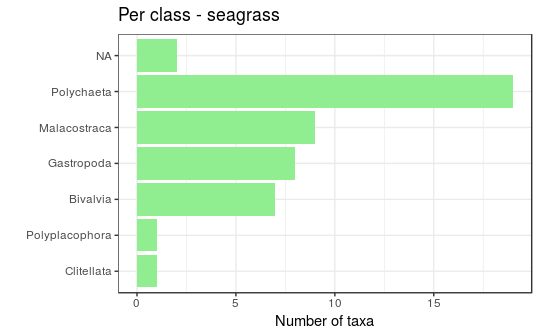

```r
## add the taxonomic classification to the 2 subsets of taxa per habitat
taxa.zostera.2012 <- left_join(taxa.zostera.2012, current.taxa.2012)
taxa.sand.2012 <- left_join(taxa.sand.2012, current.taxa.2012)
## number of taxa per class & habitat
# in seagrass
taxa.zostera.2012 %>%
  count(class, sort = TRUE) %>%
  ggplot(mapping = aes(x = reorder(class, n), y = n)) +
    geom_bar(stat = "identity", fill = "light green") +
    coord_flip() +
    labs(title = "Per class - seagrass", x = "", y = "Number of taxa") +
    theme_bw()
```

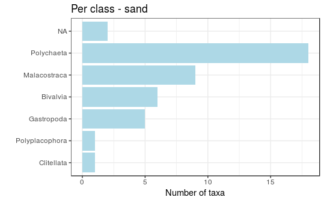

```r
# in sand
taxa.sand.2012 %>%
  count(class, sort = TRUE) %>%
  ggplot(mapping = aes(x = reorder(class, n), y = n)) +
    geom_bar(stat = "identity", fill = "light blue") +
    coord_flip() +
    labs(title = "Per class - sand", x = "", y = "Number of taxa") +
    theme_bw()
```

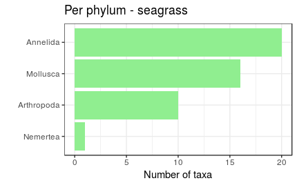

```r
## number of taxa per phylum & habitat
# in seagrass
taxa.zostera.2012 %>%
  count(phylum, sort = TRUE) %>%
  ggplot(mapping = aes(x = reorder(phylum, n), y = n)) +
    geom_bar(stat = "identity", fill = "light green") +
    coord_flip() +
    labs(title = "Per phylum - seagrass", x = "", y = "Number of taxa") +
    theme_bw()
```

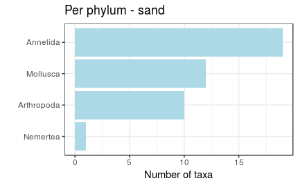

```r
# in sand
taxa.sand.2012 %>%
  count(phylum, sort = TRUE) %>%
  ggplot(mapping = aes(x = reorder(phylum, n), y = n)) +
    geom_bar(stat = "identity", fill = "light blue") +
    coord_flip() +
    labs(title = "Per phylum - sand", x = "", y = "Number of taxa") +
    theme_bw()
```

Count the number of species by taxonomic group and habitat.

```r
## in seagrass
taxa.zostera.2012 %>%
  count(group)
```

| group | n |
| --- | --- |
| Crustacea | 10 |
| Mollusca | 16 |
| Polychaeta | 19 |
| Varia | 2 |

```r
## in sand
taxa.sand.2012 %>%
  count(group)
```

| group | n |
| --- | --- |
| Crustacea | 10 |
| Mollusca | 12 |
| Polychaeta | 18 |
| Varia | 2 |

Now plot the number of taxa per (common) taxonomic group, and save as file.

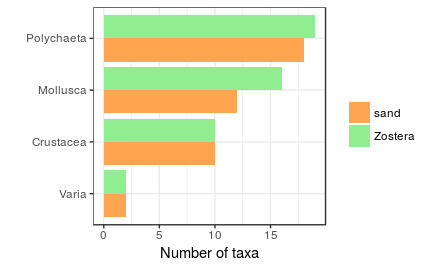

```r
nb.taxa.by.gr.habitat.2012 <- left_join(zoo.abnd.2012.long, current.taxa.2012) %>%
  group_by(habitat) %>%
  filter(sp_count > 0) %>%
  distinct(species, group) %>%
  count(group)
(plot.nb.taxa.by.gr.hab.2012 <- ggplot(nb.taxa.by.gr.habitat.2012, mapping = aes(x = reorder(group, n), y = n, fill = habitat)) +
    geom_bar(stat = "identity", position = "dodge") +
    scale_fill_manual(values=c("tan1", "light green"), name = "", labels = c("sand", "Zostera")) +
    coord_flip() +
    labs(x = "", y = "Number of taxa") +
    theme(axis.text.x = element_text(size = rel(1.3)),
          axis.text.y = element_text(size = rel(1.3))) +
    theme_bw()
)
ggsave(file.path(figures.dir, "nb_taxa_by_tax_group_2012.png"),
       plot.nb.taxa.by.gr.hab.2012,
       dpi = 300)
```

In the **seagrass** in Sozopol Bay (2012):  
+ **Crustacea** are represented by 9 families.  
+ **Polychaeta** are represented by 12 families.  
+ **Mollusca** are represented by 11 families.

The families with the highest number of species are:

```r
## in seagrass
lapply(setdiff(unique(taxa.zostera.2012$group), "Varia"),
       function(x) {
         taxa.zostera.2012 %>%
           group_by(group) %>%
           count(family) %>%
           filter(group == x) %>%
           arrange(desc(n))
       })
```

| group | family | n |
| --- | --- | --- |
| Mollusca | Rissoidae | 3 |
| Mollusca | Lucinidae | 2 |
| Mollusca | Semelidae | 2 |
| Mollusca | Veneridae | 2 |
| Mollusca | Cerithiidae | 1 |
| Mollusca | Lepidochitonidae | 1 |
| Mollusca | Mangeliidae | 1 |
| Mollusca | Muricidae | 1 |
| Mollusca | Mytilidae | 1 |
| Mollusca | Nassariidae | 1 |

[output cut: 1 more lines]

| group | family | n |
| --- | --- | --- |
| Crustacea | NA | 2 |
| Crustacea | Ampeliscidae | 1 |
| Crustacea | Aoridae | 1 |
| Crustacea | Atylidae | 1 |
| Crustacea | Balanidae | 1 |
| Crustacea | Corophiidae | 1 |
| Crustacea | Idoteidae | 1 |
| Crustacea | Upogebiidae | 1 |
| Crustacea | Varunidae | 1 |

| group | family | n |
| --- | --- | --- |
| Polychaeta | Capitellidae | 3 |
| Polychaeta | Maldanidae | 3 |
| Polychaeta | Syllidae | 3 |
| Polychaeta | Eunicidae | 2 |
| Polychaeta | Dorvilleidae | 1 |
| Polychaeta | Hesionidae | 1 |
| Polychaeta | Nereididae | 1 |
| Polychaeta | Paraonidae | 1 |
| Polychaeta | Pectinariidae | 1 |
| Polychaeta | Phyllodocidae | 1 |

[output cut: 2 more lines]

```
NA
```

In the **sands** in Sozopol Bay (2012):  
+ **Crustacea** are represented by 9 families.  
+ **Polychaeta** are represented by 13 families.  
+ **Mollusca** are represented by 11 families.

The families with the highest number of species are:

```r
## in sand
lapply(setdiff(unique(taxa.sand.2012$group), "Varia"),
       function(x) {
         taxa.sand.2012 %>%
           group_by(group) %>%
           count(family) %>%
           filter(group == x) %>%
           arrange(desc(n))
       })
```

| group | family | n |
| --- | --- | --- |
| Mollusca | Semelidae | 2 |
| Mollusca | Cardiidae | 1 |
| Mollusca | Cerithiidae | 1 |
| Mollusca | Hydrobiidae | 1 |
| Mollusca | Lepidochitonidae | 1 |
| Mollusca | Lucinidae | 1 |
| Mollusca | Mangeliidae | 1 |
| Mollusca | Muricidae | 1 |
| Mollusca | Mytilidae | 1 |
| Mollusca | Rissoidae | 1 |

[output cut: 1 more lines]

| group | family | n |
| --- | --- | --- |
| Crustacea | NA | 2 |
| Crustacea | Ampeliscidae | 1 |
| Crustacea | Aoridae | 1 |
| Crustacea | Atylidae | 1 |
| Crustacea | Balanidae | 1 |
| Crustacea | Cirolanidae | 1 |
| Crustacea | Corophiidae | 1 |
| Crustacea | Diogenidae | 1 |
| Crustacea | Upogebiidae | 1 |

| group | family | n |
| --- | --- | --- |
| Polychaeta | Spionidae | 3 |
| Polychaeta | Capitellidae | 2 |
| Polychaeta | Maldanidae | 2 |
| Polychaeta | Syllidae | 2 |
| Polychaeta | Ampharetidae | 1 |
| Polychaeta | Dorvilleidae | 1 |
| Polychaeta | Glyceridae | 1 |
| Polychaeta | Magelonidae | 1 |
| Polychaeta | Nephtyidae | 1 |
| Polychaeta | Nereididae | 1 |

[output cut: 3 more lines]

```
NA
```

Now let’s calculate the contribution of each taxonomic group to the **overall community composition by abundance**.

```r
zoo.abnd.2012.long %>%
  summarize_tax_group_contr(current.taxa.2012,
                            key.col = "species",
                            value.col = sp_count,
                            habitat, group) %>%
  arrange(habitat, desc(proportion))
```

| habitat | group | total | proportion |
| --- | --- | --- | --- |
| S | Mollusca | 507 | 0.40821256 |
| S | Polychaeta | 349 | 0.28099839 |
| S | Varia | 327 | 0.26328502 |
| S | Crustacea | 59 | 0.04750403 |
| Z | Mollusca | 2146 | 0.75457103 |
| Z | Varia | 323 | 0.11357243 |
| Z | Polychaeta | 292 | 0.10267229 |
| Z | Crustacea | 83 | 0.02918425 |

Now calculate and plot the **contribution of the taxonomic groups to the abundance by station and year** in both habitats in Sozopol Bay in 2012.

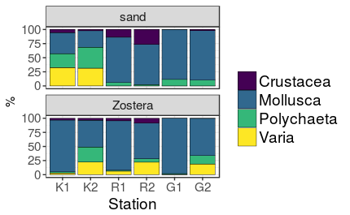

```r
tax.props.st.yr.2012 <- zoo.abnd.2012.long %>%
  summarize_tax_group_contr(current.taxa.2012,
                            key.col = "species",
                            value.col = sp_count,
                            habitat, station, group) %>%
  arrange(habitat, station)
(plot.tax.props.st.yr.2012 <- plot_tax_props(tax.props.st.yr.2012, x.labels = c("K1", "K2", "R1", "R2", "G1", "G2"), col.palette = "viridis") +
    # change the strip labels
    facet_wrap(~habitat, nrow = 2, labeller = as_labeller(c("S" = "sand", "Z" = "Zostera"))) +
    text_size(text.x = rel(1.3), text.y = rel(1.3), title.x = rel(1.3), legend.text = rel(1.3), strip.x = rel(1.3))
)
## save as file
ggsave(file.path(figures.dir, "tax_gr_props_st_yr_2012.png"),
       plot.tax.props.st.yr.2012,
       dpi = 300)
```

Check and plot the species which contribute the most to the abundance at each habitat & station.

```
Saving 15 x 7.01 cm image
```

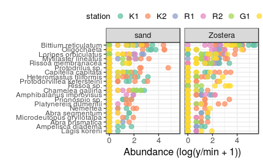

```r
top20.counts.2012.st <- get_top_sp(zoo.abnd.2012, nb.sp = 20)
plot.most.abnd.sp.2012 <- plot_top_n(top20.counts.2012.st,
                                     aes(x = species, y = log_y_min(sp_count),
                                         colour = station),
                                     labs.legend = c("K1", "K2", "R1", "R2", "G1", "G2"),
                                     lab.y = "Abundance (log(y/min + 1))",
                                     palette = "Set2"
                                     )
(plot.most.abnd.sp.2012 <- plot.most.abnd.sp.2012  +
    facet_wrap(~habitat, ncol = 2, labeller = as_labeller(c("S" = "sand", "Z" = "Zostera"))) +
    text_size(text.x = rel(1.1), title.x = rel(1.1), strip.x = rel(1.1), text.y = rel(1), legend.text = rel(0.9), legend.title = rel(0.9)) +
    theme(legend.position = "top", legend.box.spacing = unit(0.01, "cm"), legend.direction = "horizontal") +
    guides(colour = guide_legend(nrow = 1)) +
    scale_x_discrete(name = "", limits = rev(levels(top20.counts.2012.st$species)))
)
## save as file
ggsave(file.path(figures.dir, "most_abnd_sp_st_2012.png"),
       plot.most.abnd.sp.2012,
       dpi = 300, width = 15, units = "cm")
```

Now let’s calculate the same way the **overall community composition by biomass** in both habitat types in Sozopol Bay (2012).

```r
zoo.biomass.2012.long %>%
  summarize_tax_group_contr(current.taxa.2012,
                            key.col = "species",
                            value.col = sp_biomass,
                            habitat, group) %>%
  arrange(habitat, desc(proportion))
```

| habitat | group | total | proportion |
| --- | --- | --- | --- |
| S | Mollusca | 33.5176 | 0.9347105871 |
| S | Crustacea | 1.9923 | 0.0555595837 |
| S | Polychaeta | 0.2565 | 0.0071530559 |
| S | Varia | 0.0924 | 0.0025767733 |
| Z | Mollusca | 62.7254 | 0.9536344301 |
| Z | Crustacea | 2.7480 | 0.0417787278 |
| Z | Polychaeta | 0.2369 | 0.0036016669 |
| Z | Varia | 0.0648 | 0.0009851752 |

Then calculate and plot the **contribution of the taxonomic groups to the biomass by station and year** in Sozopol Bay.

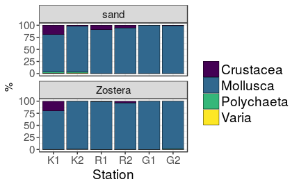

```r
tax.props.biomass.st.yr.2012 <- zoo.biomass.2012.long %>%
  summarize_tax_group_contr(current.taxa.2012,
                            key.col = "species",
                            value.col = sp_biomass,
                            habitat, station, group) %>%
  arrange(habitat, station)
# plot this
(plot.tax.props.biomass.st.yr.2012 <- plot_tax_props(tax.props.biomass.st.yr.2012, x.labels = c("K1", "K2", "R1", "R2", "G1", "G2")) +
    facet_wrap(~habitat, nrow = 2, labeller = as_labeller(c("S" = "sand", "Z" = "Zostera"))) +
    text_size(text.x = rel(1.3), text.y = rel(1.3), title.x = rel(1.3), legend.text = rel(1.3), strip.x = rel(1.3))
)
## save as file
ggsave(file.path(figures.dir, "tax_gr_props_biomass_st_yr_2012.png"),
       plot.tax.props.biomass.st.yr.2012,
       dpi = 300)
```

Combine the proportions of the abundance and the biomass in one single plot.

```
Saving 15 x 7.01 cm image
```

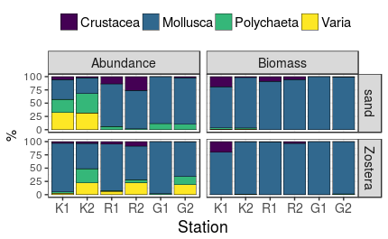

```r
## combine the proportional abundance and biomass tibbles into a single common (long) one
tax.props.2012.all <- full_join(tax.props.st.yr.2012,
                                tax.props.biomass.st.yr.2012,
                                by = c("habitat", "station", "group")) %>%
  select(-starts_with("total")) %>%
  gather(key = variable, value = proportion, -habitat, -station, -group) %>%
  ungroup() %>%
  # fix a little the variables that will serve for faceting the plot, to avoid re-labeling later
  mutate(variable = case_when(variable == "proportion.x" ~ "Abundance",
                              variable == "proportion.y" ~ "Biomass"),
         habitat = case_when(habitat == "S" ~ "sand",
                             habitat == "Z" ~ "Zostera"))
(plot.composite.tax.gr.props.2012 <- plot_tax_props(tax.props.2012.all, x.labels = c("K1", "K2", "R1", "R2", "G1", "G2")) +
    facet_grid(habitat ~ variable) +
    theme(legend.position = "top", legend.key.size = unit(0.5, "cm")) +
    text_size(text.x = rel(1.2), text.y = rel(1), title.x = rel(1.2), legend.text = rel(1), strip.x = rel(1.2), strip.y = rel(1.2))
)
ggsave(file.path(figures.dir, "tax_gr_props_2012_composite.png"),
       plot.composite.tax.gr.props.2012,
       dpi = 300, width = 15, units = "cm")
```

Check and plot the species which contribute the most to the biomass at each habitat & station.

```
Saving 15 x 7.01 cm image
```

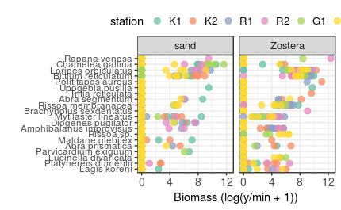

```r
## calculate the total biomass counts by species, then select the 20 with the highest biomass
top20.biomass.2012.st <- get_top_sp(zoo.biomass.2012, nb.sp = 20)
## plot them
plot.highest.biomass.sp.2012 <- plot_top_n(top20.biomass.2012.st,
                                     aes(x = species, y = log_y_min(sp_count),
                                         colour = station),
                                     labs.legend = c("K1", "K2", "R1", "R2", "G1", "G2"),
                                     lab.y = "Biomass (log(y/min + 1))",
                                     palette = "Set2"
                                     )
(plot.highest.biomass.sp.2012 <- plot.highest.biomass.sp.2012  +
    facet_wrap(~habitat, ncol = 2, labeller = as_labeller(c("S" = "sand", "Z" = "Zostera"))) +
    text_size(text.x = rel(1.2), strip.x = rel(1.1), text.y = rel(1), legend.text = rel(0.9)) +
    theme(legend.position = "top", legend.box.spacing = unit(0.01, "cm"), legend.direction = "horizontal") +
    guides(colour = guide_legend(nrow = 1)) +
    scale_x_discrete(name = "", limits = rev(levels(top20.biomass.2012.st$species)))
)

## save as file
ggsave(file.path(figures.dir, "highest_biomass_sp_st_2012.png"),
       plot.highest.biomass.sp.2012,
       dpi = 300, width = 15, units = "cm")
```

3. Site-level comparison of macrobenthic community composition & structure - seagrass/sand, Sozopol Bay, 2012

On second thought, for 2012, a more useful approach would be to 1) test whether there are differences in community composition between the pairs of stations at each of the 3 sites, in sand/seagrass - hopefully no; 2) find the top-contributing species to the abundance/biomass at the site level.

Add the site to the (long & wide) abundance & biomass datasets.

```r
library(stringr)
zoo.abnd.2012.long <- zoo.abnd.2012.long %>%
  # match 0+ characters at the beginning of the given string which are not digits - because the names of the stations here consist of site + station number.
  mutate(site = str_extract(station, "[^\\d]+")) %>%
  # rearrange to place site at the beginning of the data frame
  select(site, everything())
zoo.biomass.2012.long <- zoo.biomass.2012.long %>%
  mutate(site = str_extract(station, "[^\\d]+")) %>%
  select(site, everything())
```

Check if the community composition differs between sites (using package mvabund for fitting GLMs).

```r
library(mvabund)
## convert the abundance tibble to matrix
zoo.abnd.2012.mat <- mvabund(zoo.abnd.2012 %>% arrange(habitat) %>% select(-c(station:replicate)))
## get the sites & habitats
sites.2012 <- (zoo.abnd.2012 %>%
  mutate(site = str_extract(station, "[^\\d]+")) %>%
  arrange(habitat))$site
habitats.2012 <- sort(zoo.abnd.2012$habitat)
## check the mean-variance relationship in the dataset - for some reason RStudio doesn't want to plot this today - sth to do with graphical device size.
meanvar.plot(zoo.abnd.2012.mat)
```

```
Error in (function ()  : unused arguments (height = 8, width = 8)
```

NB Save the models & summaries as R data objects, because they take way too much time to repeat.

NB Remember to do some workspace cleanup in the end! There are too many trailing objects.